# CO2 Emission by Vehicles

Otklonili smo prekid za poprilično veliki broj tačaka, raspodela deluje koliko toliko normalno raspodeljena ali i dalje imamo “repove” koji mogu da ukazuju na one vrednosti sa visokom polugom. Možemo da pogledamo vrednost 3770.

```r
origRow <- train[3770, ]

prediction <- predict(lmCT, newdata = origRow)

origRow$predictions <- prediction

origRow_kable <- kable(origRow, format = "html") %>%
  kable_styling()

origRow_kable
```

| Make | Model | VehicleClass | EngineSize | Cylinders | Transmission | FuelType | FCCity | FCHighway | FCComb | FCCombMPG | CO2Emission | predictions |
| --- | --- | --- | --- | --- | --- | --- | --- | --- | --- | --- | --- | --- |
| CHEVROLET | EXPRESS 3500 PASSENGER FFV | VAN - PASSENGER | 6 | 8 | A6 | Ethanol | 30.6 | 20.6 | 26.1 | 11 | 418 | 483.1043 |

Opet nailazimo na ovaj problematični Chevrolet, ali sada barem ne mašimo za 100 jedinica mere kao pre, ali i dalje ovo nije baš precizna predikcija, svakako ovo je tačka sa visokom polugom u ovom slučaju pošto je potrošnja po gradu ovoliko velika.

Ideje koje možda mogu to popraviti su:

Da ne koristimo FCCity već FCComb kako bi bolje izbalansirali potrošnju, potrošnja će uvek biti veća po gradu nego na autoputu tako da bi ovakve stvari trebale malo manje da dolaze do izražaja.

Da otklonimo ove vrednosti u potpunosti što povlači za sobom lošije pretpostavke modela ako do ovakvih vrednosti dođe u realnosti jer su moguće, ovaj Chevrolet ima motor od 8 cilindara sa zapreminom od 6 kubika, nije čudno što troši ovoliko, tj. to nije greška.

Da uvrstimo kolone koje se tiču broja cilindara i kubikaže u model.

Da probamo da transformišemo FCCity nekom funckijom (log, sqrt npr.)

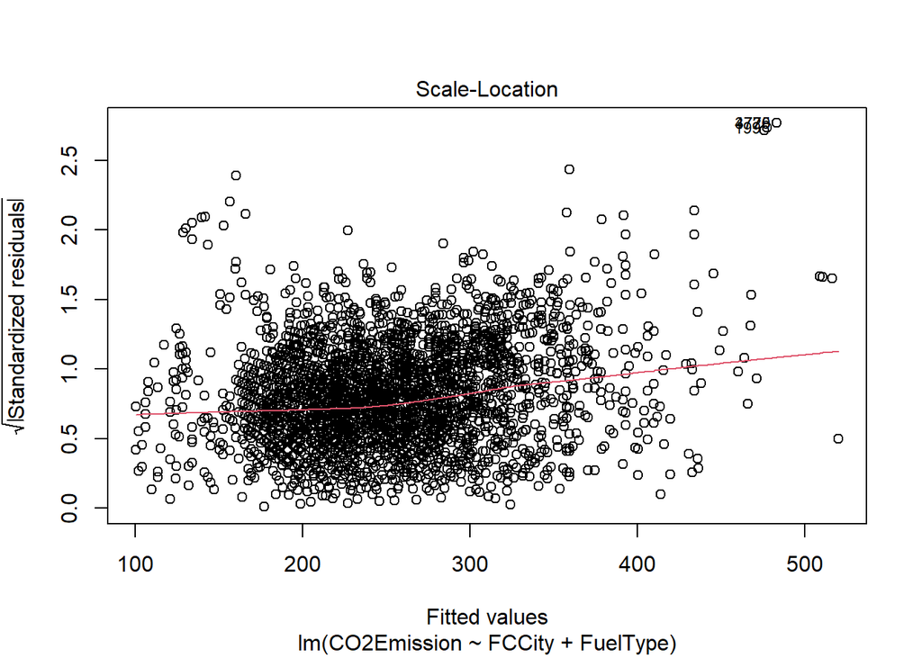

```r
plot(lmCT, which = 3)
```

**Scale location**

Sada je situacija dosta bolja ali i dalje vidimo da tačke nisu ravnomerno raspoređene po plotu što ukazujue na nekonstantnu varijansu reziduala.

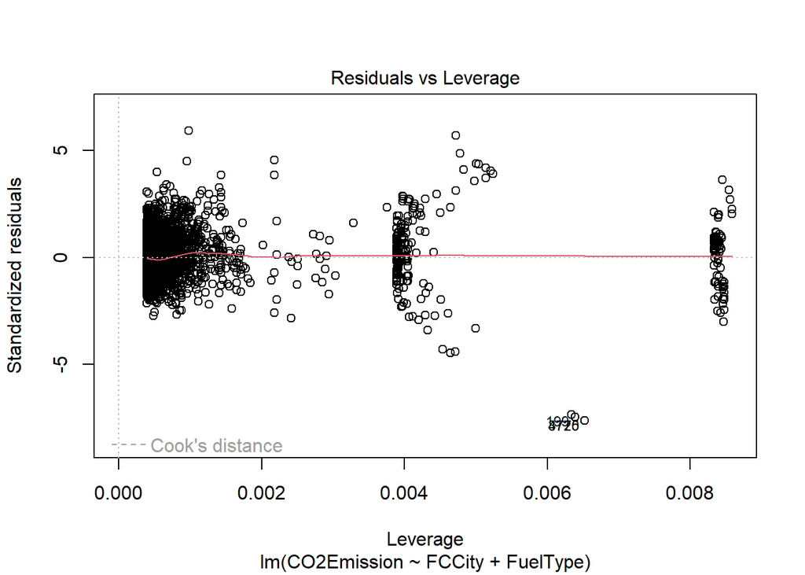

```r
plot(lmCT, which = 5)
```

**Residual vs Leverage**

Ovde je takođe bolja situacija, i dalje imamo neke uticajinje tačke ali nemamo ih puno kao u prethodnom plotu.

## Korišćenje FCComb umesto FCCity i log transformacija zavisne(CO2 emission) i prediktora(FCComb)

Prvo da pogledamo ponovo raspodele FCComb i CO2 emission

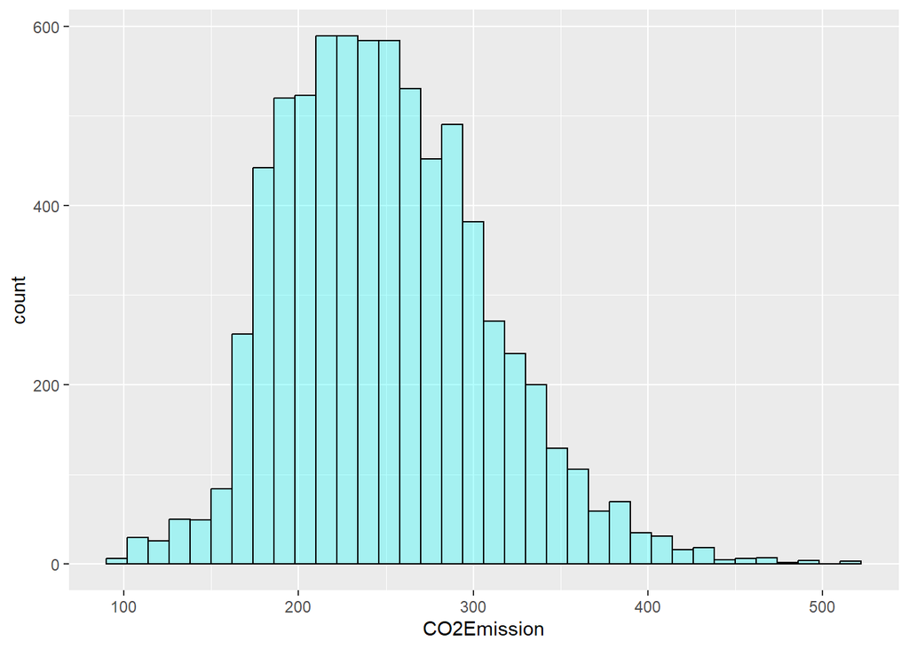

```r
ggplot(co2_emission, aes(x = CO2Emission)) +
  geom_histogram(binwidth = 12, color = "black", fill = "cyan", alpha = 0.3)
```

Za raspodelu co2 emisija vidimo da imamo nakrivljenost na desno (right skew),takođe popriličan rep vrednosti na desnoj strani plota (desno nakrivljena pošto je ‘rep’ distribucije na desnoj strani plota, a ‘grba’ je levo, za nakrivljenost na levo je obrnuto).

Šta se dešava ako logaritmujemo ove vrednosti:

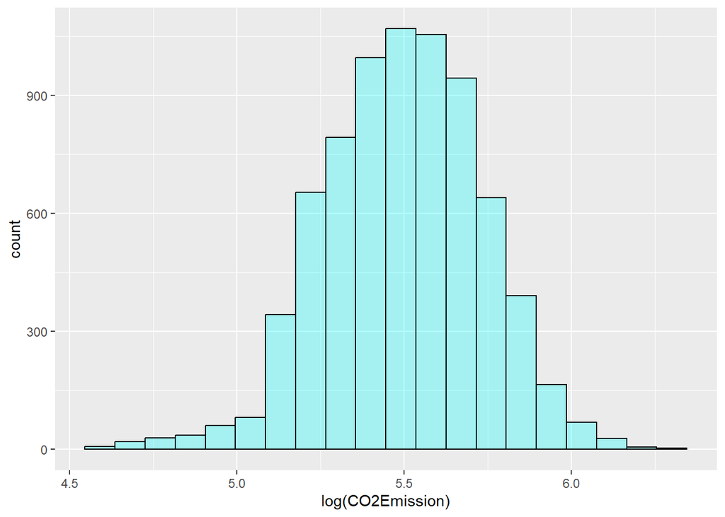

```r
ggplot(co2_emission, aes(x = log(CO2Emission))) +
  geom_histogram(binwidth = 0.09, color = "black", fill = "cyan", alpha = 0.3)
```

Vidimo da je sada rep više levo tako da je ovo možda i malo previše agresivna transformacija (sqrt je manje agresivna ali proizvodi lošije rezultate u modelu tako da je nećemo koristiti), ali svakako su sada podaci bolje raspodeljeni.

Slično za FCComb:

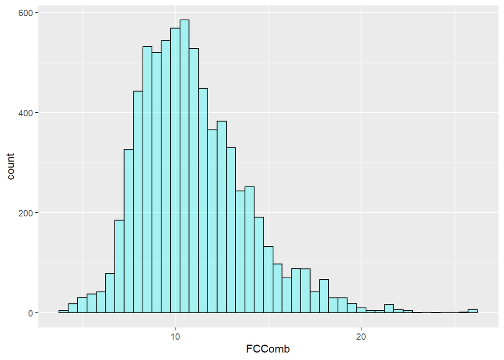

```r
ggplot(co2_emission, aes(x = FCComb)) +
  geom_histogram(binwidth = 0.5 , color = "black", fill = "cyan", alpha = 0.3)
```

Vidimo sličnu raspodelu kao i u gornjem slučaju, primenjujemo istu metodu:

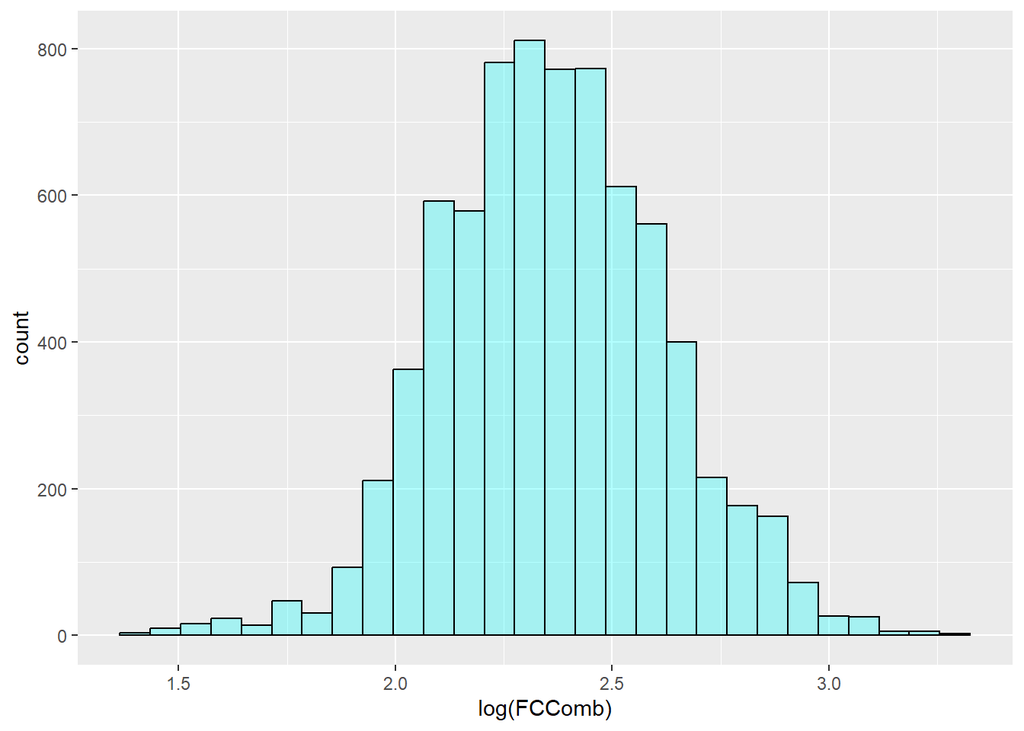

```r
ggplot(co2_emission, aes(x = log(FCComb))) +
  geom_histogram(binwidth = 0.07 , color = "black", fill = "cyan", alpha = 0.3)
```

Na osnovu ovih plotova možemo da pretpostavimo da će ovakve transformacije pomoći modelu da bolje zaključuje pošto je jedna od osnovnih pretpostavki OLS metode normalnost podataka, ali u isto vreme će malo zakomplikovati interpretaciju modela na šta ćemo se osvrnuti u sledećim koracima.

## TREĆI MODEL ~ log zavisne kolone i prediktora i FCComb umesto FCCity

```r
lmCombT <- lm(log(CO2Emission) ~ log(FCComb) + FuelType, data = train)

summary(lmCombT)
```

```
##
## Call:
## lm(formula = log(CO2Emission) ~ log(FCComb) + FuelType, data = train)
##
## Residuals:
##      Min       1Q   Median       3Q      Max
## -0.42420 -0.01173  0.00310  0.00756  0.10608
##
## Coefficients:
##                           Estimate Std. Error  t value Pr(>|t|)
## (Intercept)              3.1502541  0.0017616 1788.339  < 2e-16 ***
## log(FCComb)              0.9994889  0.0007658 1305.205  < 2e-16 ***
## FuelTypePremiumGasoline -0.0011399  0.0003760   -3.031  0.00245 **
## FuelTypeEthanol         -0.3576596  0.0009145 -391.079  < 2e-16 ***
## FuelTypeDiesel           0.1419796  0.0011676  121.603  < 2e-16 ***
## ---
## Signif. codes:  0 '***' 0.001 '**' 0.01 '*' 0.05 '.' 0.1 ' ' 1
##
## Residual standard error: 0.01247 on 5163 degrees of freedom
## Multiple R-squared:  0.9972, Adjusted R-squared:  0.9972
## F-statistic: 4.669e+05 on 4 and 5163 DF,  p-value: < 2.2e-16
```

Već kod RSE možemo da uvidimo problem koji logaritmovanje izlaza izaziva, u smislu interpretacije istog, a to je da ne možemo da poredimo ovu vrednost u kontekstu drugih modela dok je ne vratimo u originalno stanje.

Nešto slično će morati da se uradi kada budemo komentarisali slope i intercept ali to ćemo izvesti ako utvrdimo da je ovaj model najbolji koji možemo dobiti.

Hajde da proverimo RSE u kontekstu prethodnih modela

```r
origRSE = exp(summary(lmCombT)$sigma)
cat("RSE u originalnoj razmeri pre log-log transformacije:", origRSE)
```

```
## RSE u originalnoj razmeri pre log-log transformacije: 1.01255
```

Ovo je višestruku poboljšanje i svakako deluje veoma precizno, čak možda i previše

R2 i Adjusted R2 su identnični sa vrednošću od 0.9972. Ovakva vrednost deluje previše dobra da bi bila istinita, može biti da model overfittuje (i ako imamo samo dva prediktora), svakako ćemo proveriti model nad testnim podacima ako zaključimo da je ovo najbolje što možemo da uradimo.

F statistika i p vrednost i dalje ukazuju da je model statistički značajan.

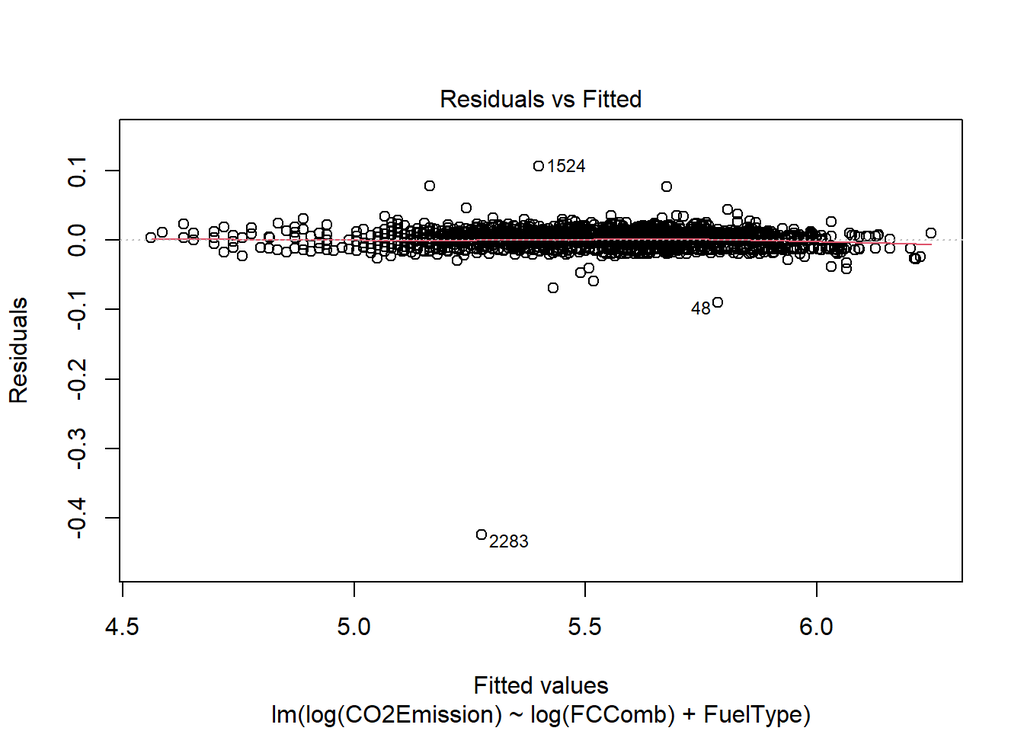

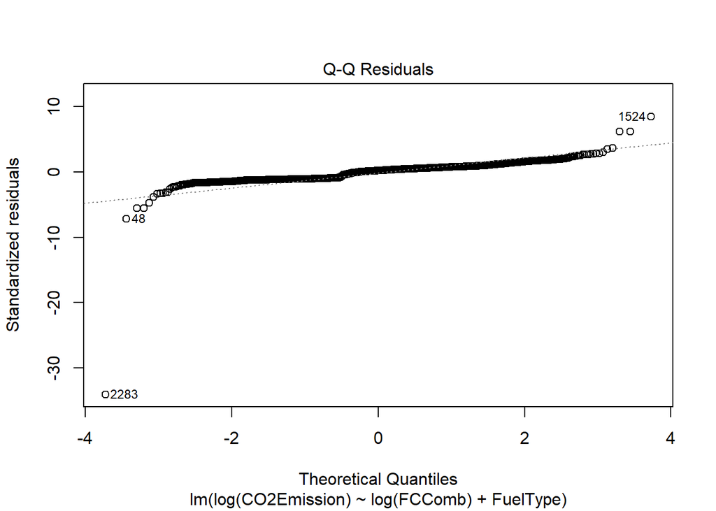

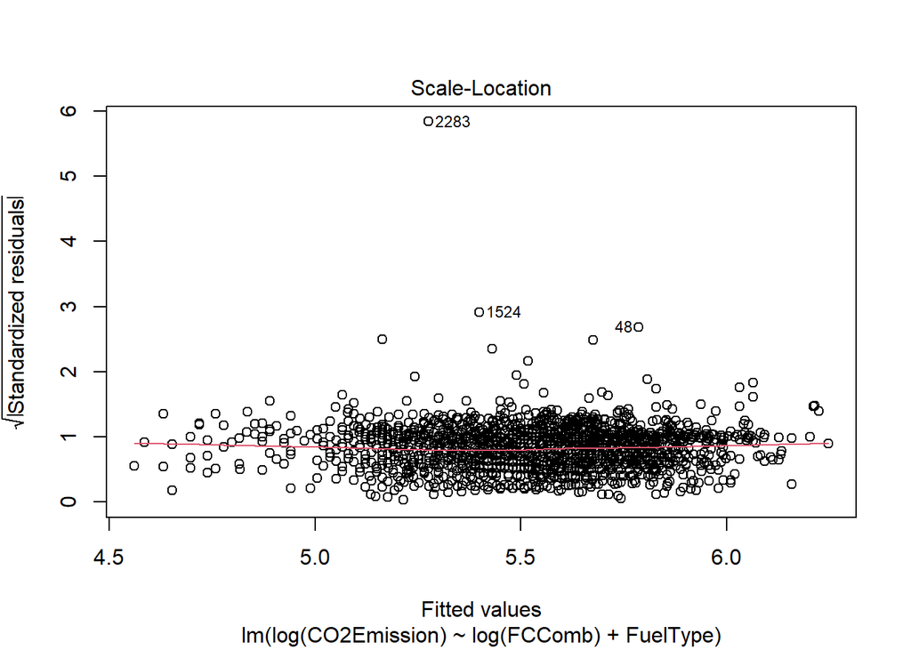

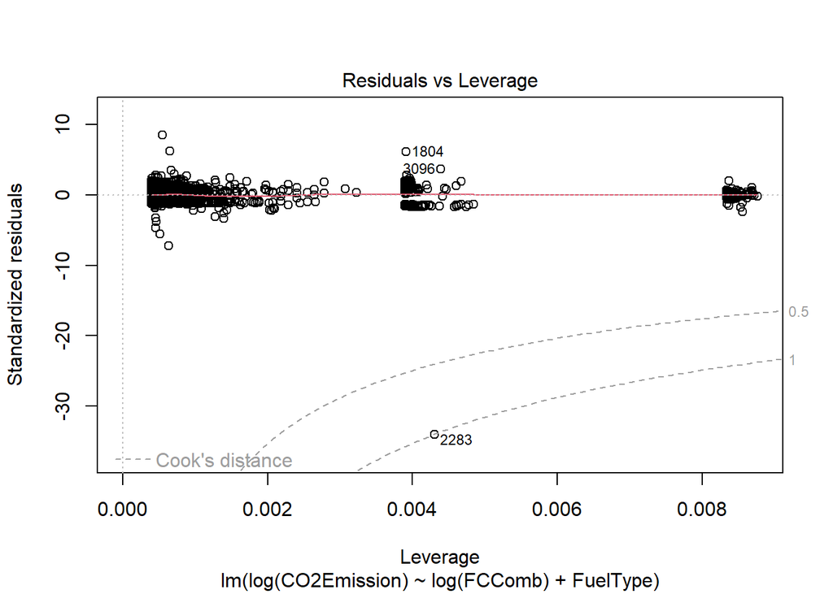

```r
plot(lmCombT)
```

Imamo još nekih tačaka koje odstupaju od generalnog trenda, but variety is the spice of life tako da ih nećemo dirati (za sada)

```r
train <- train[-2283, ]
```

## Model log-log CO2emissions ~ FCComb + FuelType bez vrednosti 2283

```r
lmLLCT <- lm(log(CO2Emission) ~ log(FCComb) + FuelType, data = train)

summary(lmLLCT)
```

```
##
## Call:
## lm(formula = log(CO2Emission) ~ log(FCComb) + FuelType, data = train)
##
## Residuals:
##       Min        1Q    Median        3Q       Max
## -0.089610 -0.011658  0.003175  0.007581  0.105989
##
## Coefficients:
##                           Estimate Std. Error  t value Pr(>|t|)
## (Intercept)              3.1514649  0.0015512 2031.637  < 2e-16 ***
## log(FCComb)              0.9989573  0.0006743 1481.410  < 2e-16 ***
## FuelTypePremiumGasoline -0.0010669  0.0003311   -3.223  0.00128 **
## FuelTypeEthanol         -0.3557157  0.0008067 -440.933  < 2e-16 ***
## FuelTypeDiesel           0.1419269  0.0010279  138.070  < 2e-16 ***
## ---
## Signif. codes:  0 '***' 0.001 '**' 0.01 '*' 0.05 '.' 0.1 ' ' 1
##
## Residual standard error: 0.01098 on 5162 degrees of freedom
## Multiple R-squared:  0.9979, Adjusted R-squared:  0.9979
## F-statistic: 6.018e+05 on 4 and 5162 DF,  p-value: < 2.2e-16
```

ovim manevrom smo uspeli da smanjimo RSE na 0.01098 sa 0.01247

Takođe imamo malo poboljšanje R2

F statistika je još veća nego u prethodnom modelu, a p vrednost je i dalje mnogo manja od 0.05 tako da je i dalje sve dobro.

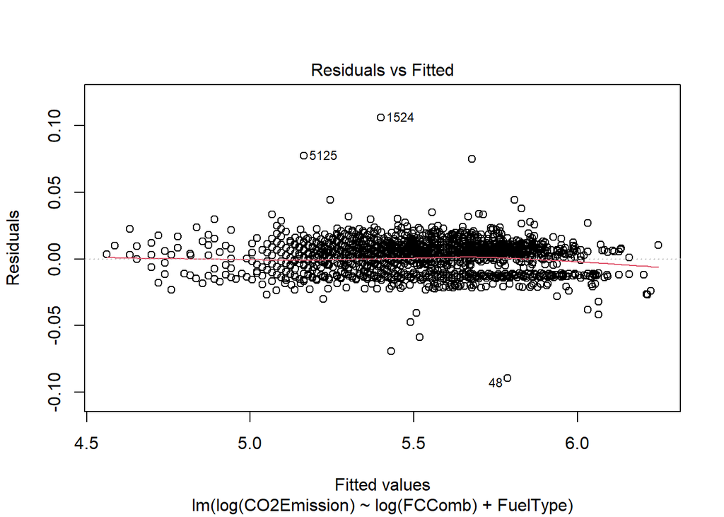

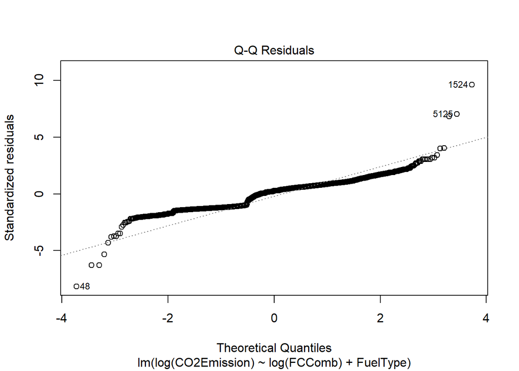

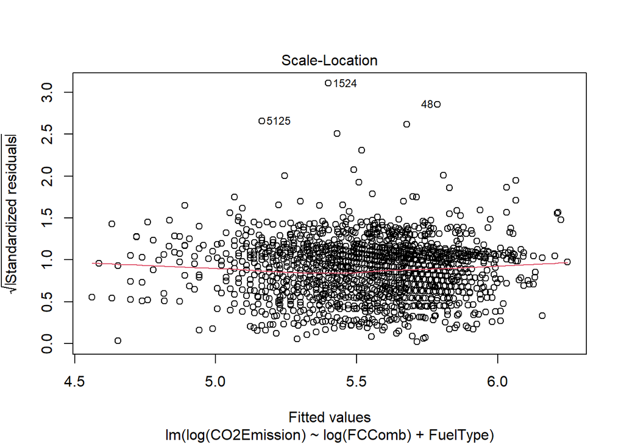

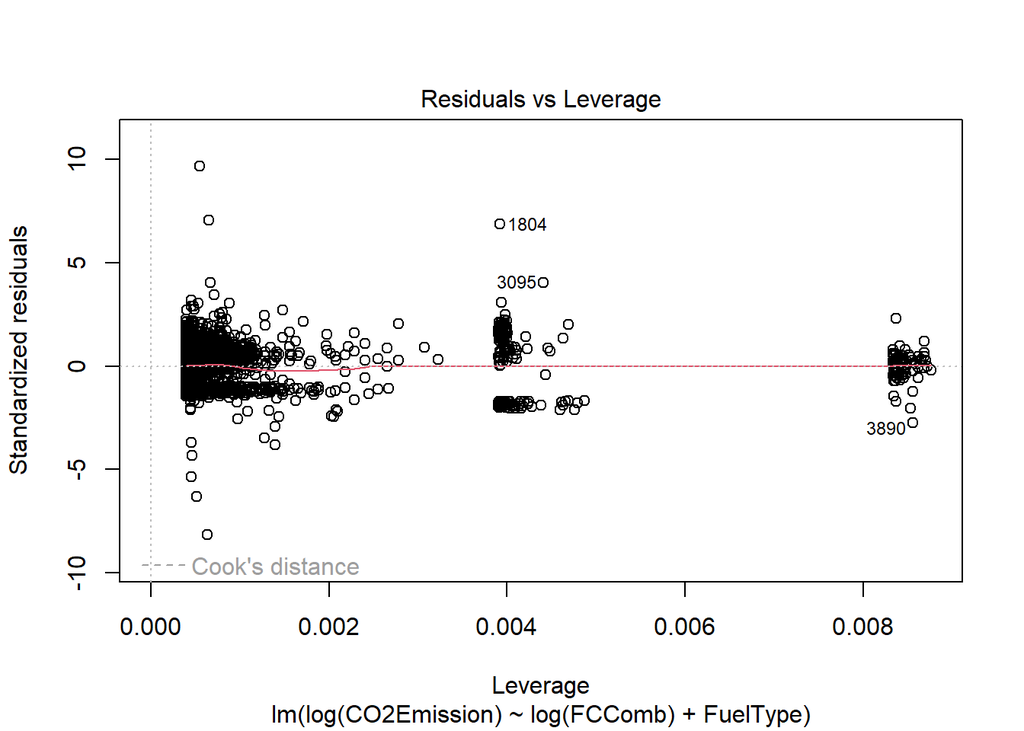

```r
plot(lmLLCT)
```

Na plotovima i dalje primećujemo dobra svojstva ali ono što sada možemo videti malo bolje je prisustvo heteroscedasticity-a u modelu do duše ne značajno, a i da imamo dosta tačaka koje odstupaju od trendova, tako da sledeće što možemo da probamo jeste da otklonimo te uticajnije tačke (iz celog dataseta pa ponovo split na test i train, seed je isti tako da bi rezultati trebali da budu isti u tom pogledu)

Ekstremne vrednosti ćemo otklanjati IQR metodom:

```r
lengthSave = length(co2_emission$FCComb)

removeOutliersIQR <- function(data, column) {
  q1 <- quantile(data[[column]], 0.25)
  q3 <- quantile(data[[column]], 0.75)
  iqr <- q3 - q1
  lower_bound <- q1 - 1.5 * iqr
  upper_bound <- q3 + 1.5 * iqr

  data[!(data[[column]] < lower_bound | data[[column]] > upper_bound), ]
}

co2_emission <- removeOutliersIQR(co2_emission, "CO2Emission")

co2_emission <- removeOutliersIQR(co2_emission, "FCComb")

lengthSave
```

```
## [1] 7384
```

```r
length(co2_emission$FCComb)
```

```
## [1] 7199
```

```r
co2_emission$FuelType = factor(co2_emission$FuelType, levels = levelsFT)

index_train <- sample(seq_len(nrow(co2_emission)), 0.7 * nrow(co2_emission))

train <- co2_emission[index_train, ]

test<- co2_emission[-index_train, ]
```

Sada ponovo treniramo model

```r
lmLLCTNoOutliers <- lm(log(CO2Emission) ~ log(FCComb) + FuelType, data = train)

summary(lmLLCTNoOutliers)
```

```
##
## Call:
## lm(formula = log(CO2Emission) ~ log(FCComb) + FuelType, data = train)
##
## Residuals:
##      Min       1Q   Median       3Q      Max
## -0.42578 -0.01172  0.00289  0.00738  0.07802
##
## Coefficients:
##                           Estimate Std. Error  t value Pr(>|t|)
## (Intercept)              3.1471676  0.0017965 1751.856  < 2e-16 ***
## log(FCComb)              1.0008216  0.0007825 1278.966  < 2e-16 ***
## FuelTypePremiumGasoline -0.0009853  0.0003678   -2.679  0.00742 **
## FuelTypeEthanol         -0.3563018  0.0010017 -355.680  < 2e-16 ***
## FuelTypeDiesel           0.1424605  0.0011368  125.317  < 2e-16 ***
## ---
## Signif. codes:  0 '***' 0.001 '**' 0.01 '*' 0.05 '.' 0.1 ' ' 1
##
## Residual standard error: 0.01213 on 5034 degrees of freedom
## Multiple R-squared:  0.9972, Adjusted R-squared:  0.9972
## F-statistic: 4.434e+05 on 4 and 5034 DF,  p-value: < 2.2e-16
```

Na osnovu vrednosti za RSE i F statistike deluje da smo zapravo pogoršali model ovom transformacijom tako da odustajemo od ovog pristupa za sad.

Hajde da proverimo ovaj model nad testnim skupom:

```r
testSave = test

columns_to_log <- c("CO2Emission", "FCComb")
testSave[columns_to_log] <- log(test[columns_to_log])

log_predictions <- predict(lmLLCT, newdata = testSave)

predictions <- exp(log_predictions)

library(Metrics)
actual_values <- test$CO2Emission

rmse_value <- rmse(predictions, actual_values)
mae_value <- mae(predictions, actual_values)

cat("RMSE:", rmse_value, "\n")
```

```
## RMSE: 200.0604
```

```r
cat("MAE:", mae_value, "\n")
```

```
## MAE: 193.6771
```

Veće greške više utiču na RMSE nego na MAE, a možemo reći da MAE posmatra sve greške jednako, svakako u našem modelu ove dve greške su slične što je dobra karakteristika, ono što nije dobro je to da je ta greška kod nas masivna, 200 jedinica, ovaj model ćemo definitivno odbaciti.

(Možda je i slučaj da nam back transformacija nije dobra, tj. da ne možemo dobiti pravu vrednost tako što radimo ovde, korišćenjem e^prediction, ali nakon 6 sati gubljenja vremena pokušavajući da nadjemo drugačiji način odustajemo od ovog modela )

Možemo da probamo da napravimo bolji model korišćenjem drugačijih prediktora što ćemo i uraditi

## Model bez log transformacija ali sa FCComb umesto FCCity

```r
lmCTNoLog= lm(CO2Emission ~ FCComb + FuelType, data = train)
summary(lmCTNoLog)
```

```
##
## Call:
## lm(formula = CO2Emission ~ FCComb + FuelType, data = train)
##
## Residuals:
##     Min      1Q  Median      3Q     Max
## -44.403  -2.840   0.553   1.909  37.329
##
## Coefficients:
##                           Estimate Std. Error  t value Pr(>|t|)
## (Intercept)                1.59984    0.24919    6.420 1.49e-10 ***
## FCComb                    23.15505    0.02371  976.594  < 2e-16 ***
## FuelTypePremiumGasoline   -0.01877    0.11592   -0.162    0.871
## FuelTypeEthanol         -107.05721    0.32336 -331.076  < 2e-16 ***
## FuelTypeDiesel            31.35297    0.35951   87.211  < 2e-16 ***
## ---
## Signif. codes:  0 '***' 0.001 '**' 0.01 '*' 0.05 '.' 0.1 ' ' 1
##
## Residual standard error: 3.837 on 5034 degrees of freedom
## Multiple R-squared:  0.9951, Adjusted R-squared:  0.9951
## F-statistic: 2.569e+05 on 4 and 5034 DF,  p-value: < 2.2e-16
```

I dalje vidimo dobre rezultate u plotu, grešimo za 3.8 jedinca

R2 je odličan sa 0.9951

F statisitka je manja nego u prethodnim modelima ali i dalje dovoljno velika i p vrednost je dovoljno mala, ovo je statistički važan model

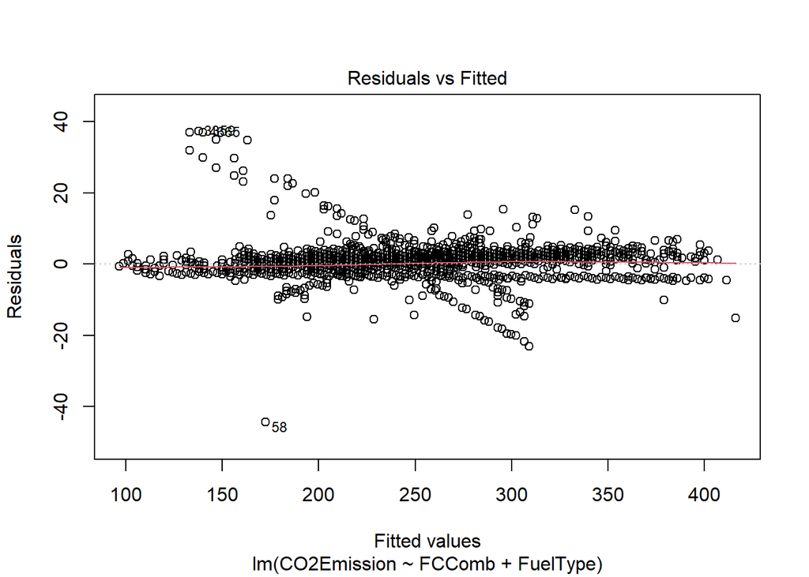

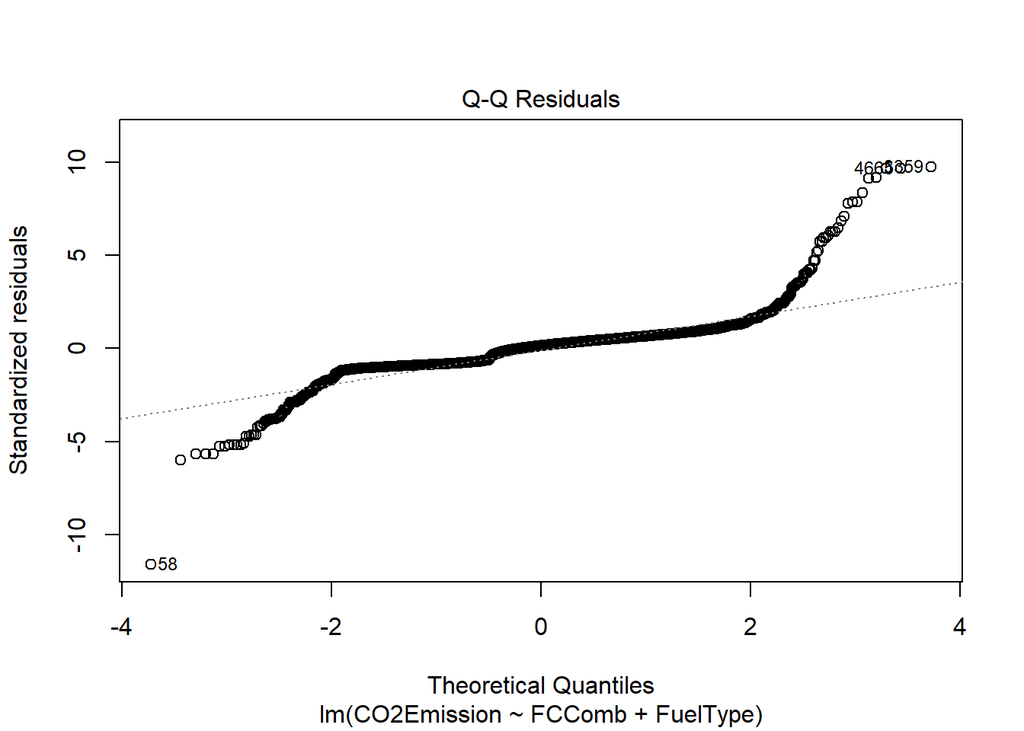

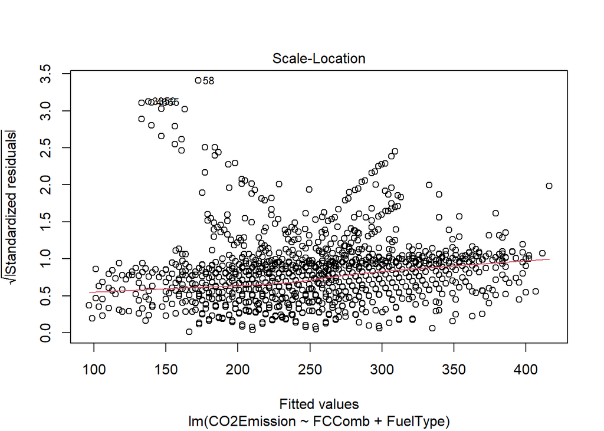

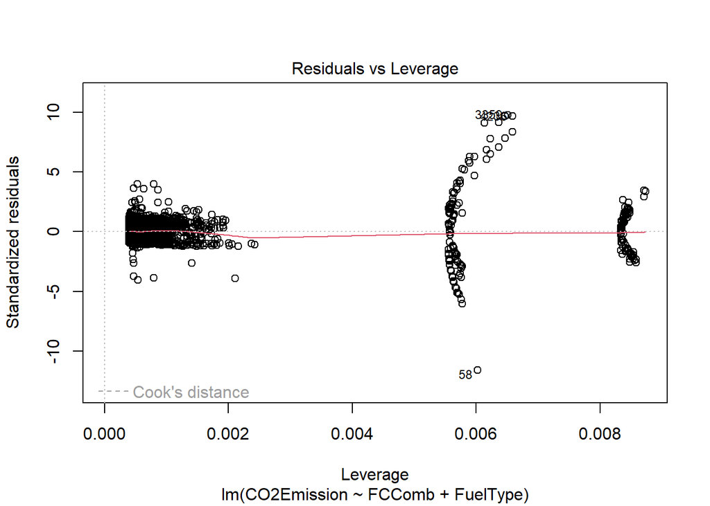

```r
plot(lmCTNoLog)
```

Na statističkim plotovima primećujemo da imamo nekakvu vrstu artefakta koja se odlikuje dijagonalnim rasprostranjenjem jednog dela tačaka na Residuals vs Fitted plotu, takođe na scale location plotu primećujemo čudne obrasce.

Na qq plotu takođe možemo primetiti loše odlike.

Na residuals vs leverage možemo videti 3 različite grupe tačaka, dok prva grupa sa leve strane nema neki primetan obrazac, druge dve imaju, zašto?

Prva stvar koja pada napamet je da ovo izazivaju tipovi goriva, tj. da automatsko enkodiranje u modelu koje odbacuje jednu kategoriju goriva izaziva ovakvo ponašanje.

Možemo da probamo da sami enkodiramo ovu promenljivu kako bi probali da otklonimo ovaj problem.

```r
dummy_variables <- model.matrix(~FuelType - 1, data = train)

train<- cbind(train, dummy_variables)
```

Ovo je varjanta one hot enkodiranja, proizvodi zasebne kolone za sve kategorije, i sada bi trebali da odbacimo jednu kolonu koja će biti pretpostavljena na osnovu pripadnosti reda u ostale 3 (imamo 4 tipa goriva), ali eksperimenta radi zardžaćemo sve kolone da vidimo šta će se desiti

```r
lmManualEncode <- lm(CO2Emission ~ FCComb + FuelTypeGasoline + FuelTypePremiumGasoline + FuelTypeDiesel + FuelTypeEthanol, data = train)
summary(lmManualEncode)
```

```
##
## Call:
## lm(formula = CO2Emission ~ FCComb + FuelTypeGasoline + FuelTypePremiumGasoline +
##     FuelTypeDiesel + FuelTypeEthanol, data = train)
##
## Residuals:
##     Min      1Q  Median      3Q     Max
## -44.403  -2.840   0.553   1.909  37.329
##
## Coefficients: (1 not defined because of singularities)
##                           Estimate Std. Error t value Pr(>|t|)
## (Intercept)             -105.45738    0.46562  -226.5   <2e-16 ***
## FCComb                    23.15505    0.02371   976.6   <2e-16 ***
## FuelTypeGasoline         107.05721    0.32336   331.1   <2e-16 ***
## FuelTypePremiumGasoline  107.03844    0.31356   341.4   <2e-16 ***
## FuelTypeDiesel           138.41018    0.47886   289.0   <2e-16 ***
## FuelTypeEthanol                 NA         NA      NA       NA
## ---
## Signif. codes:  0 '***' 0.001 '**' 0.01 '*' 0.05 '.' 0.1 ' ' 1
##
## Residual standard error: 3.837 on 5034 degrees of freedom
## Multiple R-squared:  0.9951, Adjusted R-squared:  0.9951
## F-statistic: 2.569e+05 on 4 and 5034 DF,  p-value: < 2.2e-16
```

Ono što govori da smo sve ovo radili za džabe su identični rezultati, a poredn njih i ovaj warning

**Coefficients: (1 not defined because of singularities)**

Što znači da model sam po sebi odbacuje jednu od kategorija kada vrši treniranje, možemo da primetimo da su statistike za prediktor FuelTypeEthanol NA, tj. on je bio odačen, u suprotnom bi imali savršenu multikolinearnost između ovih kategorija, svakako ovo se mora uraditi ovako hteli mi to ili ne pošto se ta odbačena kolona uzima kao baza za kalkulacije ostalih.

To znači da rešenje našeg problema leži negde drugde, idemo dalje.

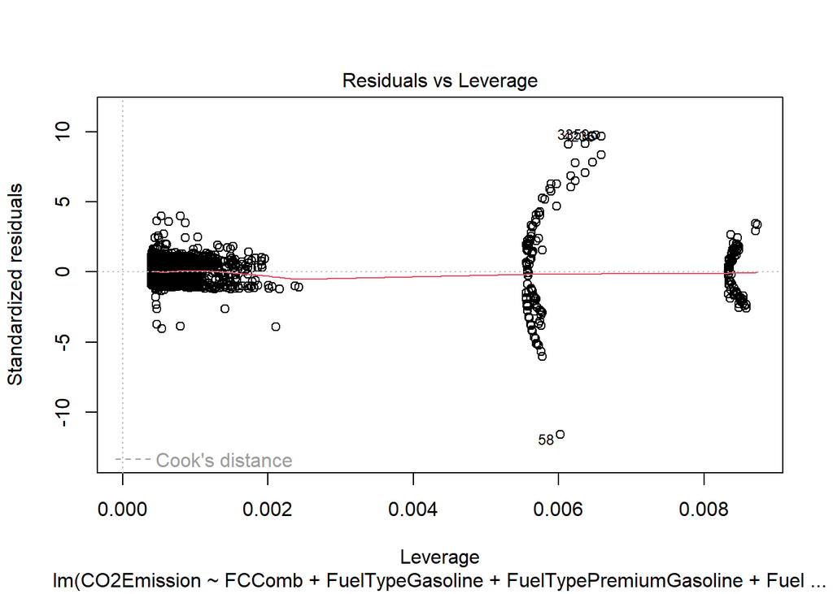

```r
plot(lmManualEncode, which = 5)
```

Ove polukružne oblike koje primećujemo na Residuals vs Leverage plotu možemo objasniti time da za neke dve grupe goriva važi da imaju dosta veliki uticaj na naš linearan model a da u isto vreme grešimo u njihovom predvidjanju i to što im je uticaj veći da više grešimo.

Nešto nam fali u modelu očigledno, ne možemo da objasnimo emisije CO2 samo sa potrošnjom i tipom goriva. Ali da li kombinacija ove dve promenljive može to da uradi, u trenutnom slučaju gledamo kako potrošnja i tip goriva deluju na emisije odvojeno, a znamo da će potrošnja zavisiti dosta od tipa goriva, dizel u velikom broju slučajeva će imati manju potrošnju nego običan benzin, na osnovu toga u model možemo da ubacimo interakciju izmedju ova dva prediktora.

```r
lmFinal = lm(CO2Emission ~ FCComb + FuelType + (FCComb * FuelType), data = train)
summary(lmFinal)
```

```
##
## Call:
## lm(formula = CO2Emission ~ FCComb + FuelType + (FCComb * FuelType),
##     data = train)
##
## Residuals:
##     Min      1Q  Median      3Q     Max
## -66.641  -2.510   0.676   1.855  21.255
##
## Coefficients:
##                                Estimate Std. Error t value Pr(>|t|)
## (Intercept)                    -0.02155    0.24615  -0.088    0.930
## FCComb                         23.31710    0.02396 973.281  < 2e-16 ***
## FuelTypePremiumGasoline         0.16558    0.39170   0.423    0.673
## FuelTypeEthanol                -6.90490    1.63600  -4.221 2.48e-05 ***
## FuelTypeDiesel                  0.52096    1.53218   0.340    0.734
## FCComb:FuelTypePremiumGasoline -0.03497    0.03566  -0.980    0.327
## FCComb:FuelTypeEthanol         -6.51980    0.10622 -61.382  < 2e-16 ***
## FCComb:FuelTypeDiesel           3.50500    0.17009  20.607  < 2e-16 ***
## ---
## Signif. codes:  0 '***' 0.001 '**' 0.01 '*' 0.05 '.' 0.1 ' ' 1
##
## Residual standard error: 2.815 on 5031 degrees of freedom
## Multiple R-squared:  0.9974, Adjusted R-squared:  0.9974
## F-statistic: 2.733e+05 on 7 and 5031 DF,  p-value: < 2.2e-16
```

Primećujemo pad RSE, za celu jedinicu mere, što je solidno u ovom slučaju (pad sa 3.8 na 2.8)

R2 i Adjusted R2 su identični i imamo blagi porast i u toj statistici, što je takođe dobro

P vrednost nam ukazuje na to da je model statistički bitan.

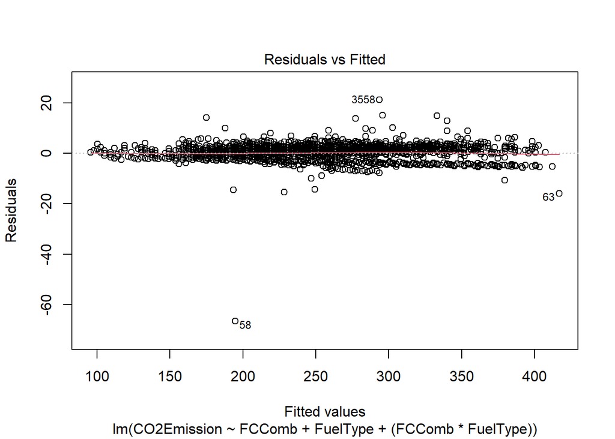

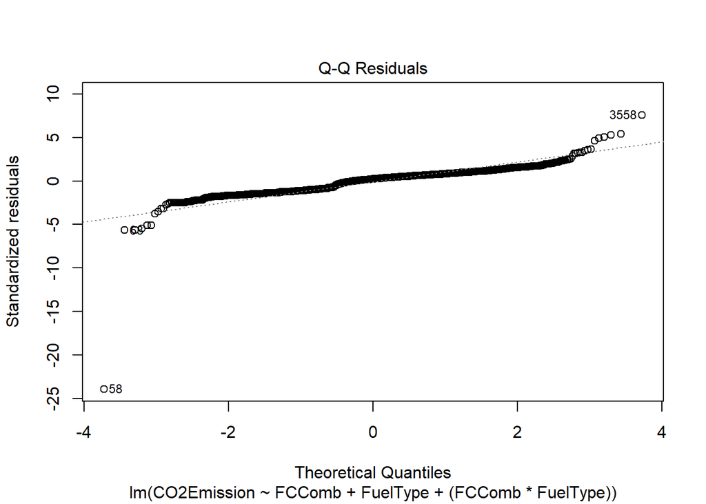

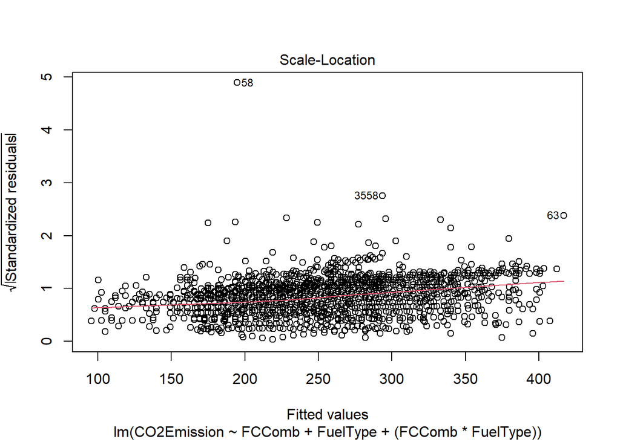

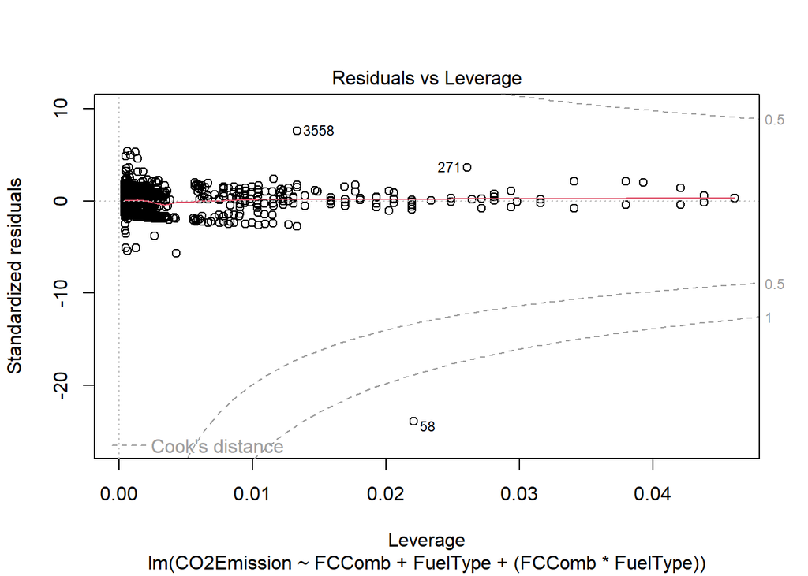

```r
plot(lmFinal)
```

Na Residuals vs Fitted vidimo da naši reziduali u velikoj većini ne odstupaju puno od 0, što je odlično.

Na qq plotu vidimo mnogo bolja svojstva, normalnost reziduala je prihvatljiva, sem za tačku 58 (to je tačka 2283 koju smo već uklanjali, ona nije outlier već ima visoku polugu pa je ostala u datasetu kada smo ga čistili, nju ćemo skloniti)

Na scale localtion plotu vidimo blag oblik levka, i linija nije savršeno horizontalna ali to ćemo ostaviti za sad takvim i videti šta se dešava nakon što otklonimo tačku sa visokom polugom (58)

Evidentno je da smo bili u pravu povodom 58. reda pošto ova tačka leži van linija Kukove distance, definitivno ćemo je otkloniti.

```r
train <- train[-58,]
```

```r
lmFinal = lm(CO2Emission ~ FCComb + FuelType + (FCComb * FuelType), data = train)
summary(lmFinal)
```

```
##
## Call:
## lm(formula = CO2Emission ~ FCComb + FuelType + (FCComb * FuelType),
##     data = train)
##
## Residuals:
##      Min       1Q   Median       3Q      Max
## -15.8943  -2.5104   0.6603   1.8456  21.6496
##
## Coefficients:
##                                Estimate Std. Error  t value Pr(>|t|)
## (Intercept)                    -0.02155    0.23173   -0.093    0.926
## FCComb                         23.31710    0.02255 1033.828   <2e-16 ***
## FuelTypePremiumGasoline         0.16558    0.36876    0.449    0.653
## FuelTypeEthanol                -1.53610    1.55459   -0.988    0.323
## FuelTypeDiesel                  0.52096    1.44245    0.361    0.718
## FCComb:FuelTypePremiumGasoline -0.03497    0.03358   -1.041    0.298
## FCComb:FuelTypeEthanol         -6.84179    0.10079  -67.878   <2e-16 ***
## FCComb:FuelTypeDiesel           3.50500    0.16013   21.889   <2e-16 ***
## ---
## Signif. codes:  0 '***' 0.001 '**' 0.01 '*' 0.05 '.' 0.1 ' ' 1
##
## Residual standard error: 2.651 on 5030 degrees of freedom
## Multiple R-squared:  0.9977, Adjusted R-squared:  0.9977
## F-statistic: 3.081e+05 on 7 and 5030 DF,  p-value: < 2.2e-16
```

Smanjili smo RSE tako da smatramo ovo uspešnim potezom.

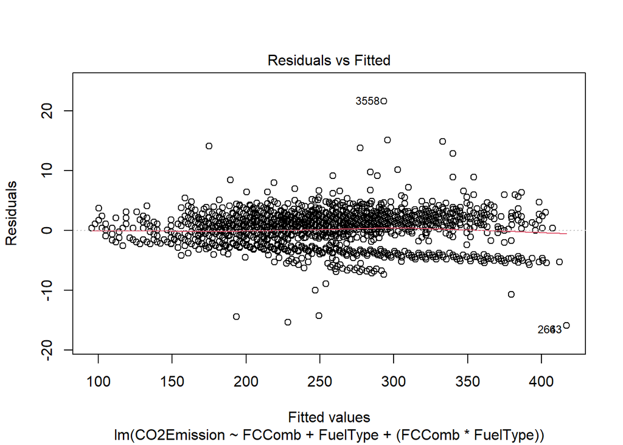

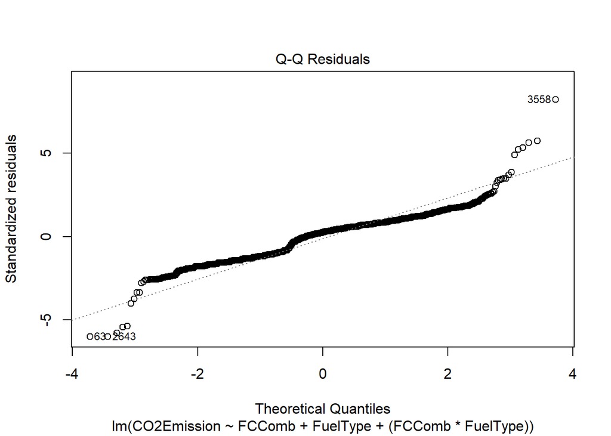

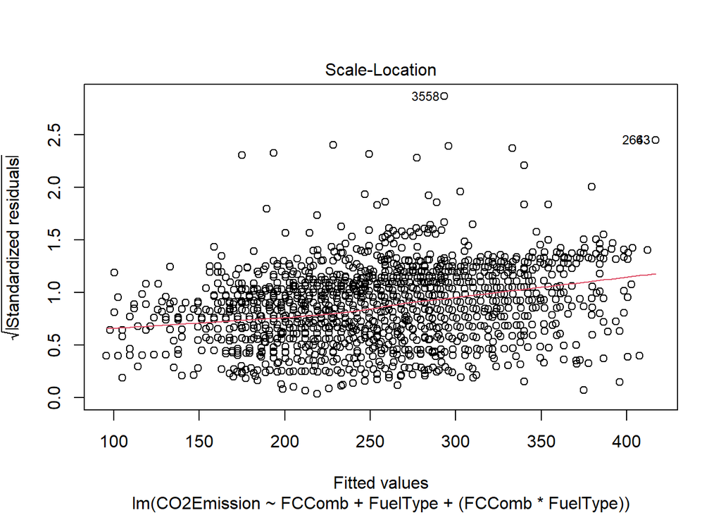

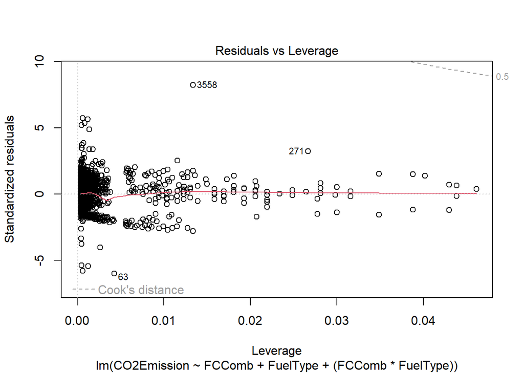

```r
plot(lmFinal)
```

Na statističkim plotovima vidimo mesta za dalja poboljšanja ovog modela ali ćemo ga smatrati finalnim,

Problemi koje primećujemo:

Deluje da imamo heteroscedasticity koji je verovatno povezan sa prethodnim problemom

Reziduali i dalje nisu baš normalno raspodeljeni

Interpretaciju koeficijenata ćemo obaviti nakon testiranja modela nad testnim skupom.

```r
dummy_variables <- model.matrix(~FuelType - 1, data = test)

test<- cbind(test, dummy_variables)
```

```r
predictions <- predict(lmFinal, newdata = test)

actual_values <- test$CO2Emission

rmse_value <- rmse(predictions, actual_values)
mae_value <- mae(predictions, actual_values)

cat("RMSE:", rmse_value, "\n")
```

```
## RMSE: 2.802577
```

```r
cat("MAE:", mae_value, "\n")
```

```
## MAE: 2.178365
```

Vidimo odlične rezultate modela nad testnim skupom

RMSE i MAE su slični, i pored toga njihova vrednost je oko 2 jedinice mere što je odlično pošto nam se vrednosti kreću od 100 do 400.

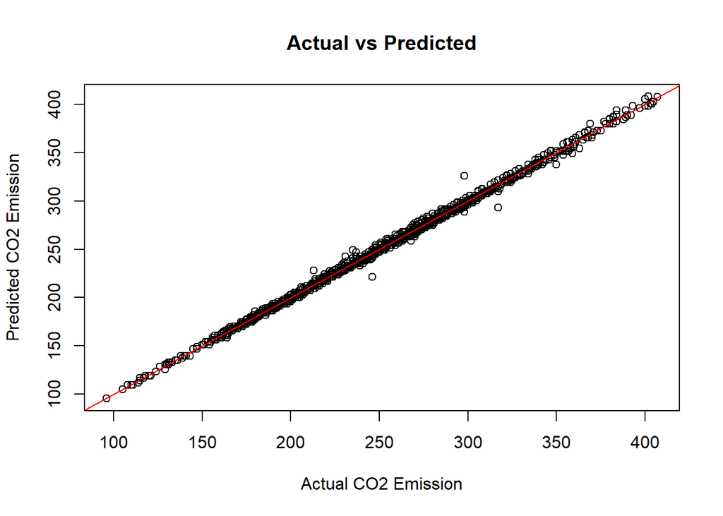

```r
plot(actual_values, predictions, main = "Actual vs Predicted",
     xlab = "Actual CO2 Emission", ylab = "Predicted CO2 Emission")

abline(a = 0, b = 1, col = "red")
```

Sa actual vs predicted plota možemo da vidimo da smo poprilično precizni sa predikcijama, naše tačke konformišu dijagonalnoj liniji kroz plot što znači da ne mašimo mnogo u pretpostavkama.

## Spoljašnji podaci za testiranje

Pošto smo dobili rezultate koji su previše dobri da im poverujemo, možemo da uzmemo još jedan dataset i da testiramo nad njim.

Pored toga, ovim datasetom možemo još jednom da testiramo hipotezu sa početka da model treniran nad podacima iz serverne Amerike neće predviđati dobro za podatke koji su na primer iz Evrope, a ovaj dataset sadrži podatke o registrovanim vozilima između 2000 i 2013 u Velikoj Britaniji.

Izvor dataseta: https://old.datahub.io/dataset/car-fuel-consumptions-and-emissions

```r
ukData = read_csv("data.csv")
problems(ukData)
```

```
## # A tibble: 2 × 5
##     row   col expected actual file
##   <int> <int> <chr>    <chr>  <chr>
## 1 45495    24 a double N/A    C:/Users/LmArK/Desktop/CO2_UNOP/data.csv
## 2 45496    24 a double N/A    C:/Users/LmArK/Desktop/CO2_UNOP/data.csv
```

Dataset ima neke greške ali pošto ima 45000 redova možemo da ih samo sklonimo, ne gubimo ništa.

```r
rows_with_issues <- c(45495, 45496)

ukData<- ukData[-rows_with_issues, ]

str(ukData)
```

```
## tibble [45,509 × 31] (S3: tbl_df/tbl/data.frame)
##  $ file                  : chr [1:45509] "DatapartC_july2000.csv" "DatapartC_july2000.csv" "DatapartC_july2000.csv" "DatapartC_july2000.csv" ...
##  $ year                  : num [1:45509] 2000 2000 2000 2000 2000 2000 2000 2000 2000 2000 ...
##  $ manufacturer          : chr [1:45509] "Alfa Romeo" "Alfa Romeo" "Alfa Romeo" "Alfa Romeo" ...
##  $ model                 : chr [1:45509] "145 Range" "145 Range" "145 Range" "146 Range" ...
##  $ description           : chr [1:45509] "1.6 Twin Spark 16v" "1.8 Twin Spark 16v" "Cloverleaf" "1.6 Twin Spark 16v" ...
##  $ euro_standard         : num [1:45509] 2 2 2 2 2 2 2 2 2 2 ...
##  $ tax_band              : chr [1:45509] NA NA NA NA ...
##  $ transmission          : chr [1:45509] "M5" "M5" "M5" "M5" ...
##  $ transmission_type     : chr [1:45509] "Manual" "Manual" "Manual" "Manual" ...
##  $ engine_capacity       : num [1:45509] 1598 1747 1970 1598 1747 ...
##  $ fuel_type             : chr [1:45509] "Petrol" "Petrol" "Petrol" "Petrol" ...
##  $ urban_metric          : num [1:45509] 11.1 11.5 12.4 11.3 11.5 12.4 11.4 11.4 11.7 11.7 ...
##  $ extra_urban_metric    : num [1:45509] 6.5 6.6 6.6 6.6 6.6 6.6 6.4 6.4 6.6 6.6 ...
##  $ combined_metric       : num [1:45509] 8.2 8.4 8.8 8.3 8.4 8.8 8.2 8.2 8.5 8.5 ...
```

[output cut: 17 more lines]

Suzdržaćemo se od detaljne analize ovog dataseta ali ono što je bitno jeste da ovaj dataset poseduje kolone koje odgovaraju našim prediktorskim kolonama u modelu, a to su tip goriva i kombinovana potrošnja.

Stoga, kolone koje nas zanimaju su:

**fuel_type** - tip goriva, za ovu kolonu moramo da preimenujemo nazive kategorija i da je enkodiramo

**combined_metric** - pošto nisu dati opisi za kolone, moraćemo da se malo bavimo pretpostavljanjem, u originalnom datasetu kombinovana potrošnja je računata ovako:

City and highway fuel consumption ratings are shown in litres per 100 kilometres (L/100 km) - **the combined rating (55% city, 45% hwy)** is shown in L/100 km and in miles per gallon (mpg)

Račun sprovodimo nad kolonama urban metric i extra urban metric (extra - van, u ovom slučaju van grada)

```r
combCalculated = ukData[1,]$urban_metric * 0.55 + ukData[1,]$extra_urban_metric * 0.45

combCalculated
```

```
## [1] 9.03
```

```r
ukData[1,]$combined_metric
```

```
## [1] 8.2
```

Ipak ovde nije korišćena ista metodologija, do duše svakako možemo da sračunamo vrednosti koje nama odgovaraju

```r
ukDataClean <- data.frame(
  FCComb = ukData$urban_metric * 0.55 + ukData$extra_urban_metric * 0.45,
  CO2Emission = ukData$co2
)
```

A sada za tipove goriva:

```r
unique(ukData$fuel_type)
```

```
##  [1] "Petrol"                   "Diesel"
##  [3] "LPG"                      "Petrol Hybrid"
##  [5] "CNG"                      "Petrol Electric"
##  [7] "LPG / Petrol"             "Petrol / E85 (Flex Fuel)"
##  [9] "Petrol / E85"             "Diesel Electric"
## [11] "Electricity/Petrol"       "Electricity"
## [13] "Electricity/Diesel"
```

Ovde uvidjamo par problema, a to je da nemamo direktno preslikavanje tipova goriva kakvi postoje u našem datasetu za trening

Petrol - Nemamo distinkciju izmedju običnog benzina i premium benzina, sve ćemo ih spakovati u običan benzin i nadati se najboljem, svakako mogli smo u originalnom modelu da spojimo premium benzin i običan u jednu promenljivu jer smo videli pri analizi podataka da ne postoji nekakva značajna razlika između ova dva goriva kada su u pitanju emisije CO2, što može da znači i da model istreniran nad takvim podacima može da dođe do sličnih zaključaka.

Petrol/E85 - (https://en.wikipedia.org/wiki/E85) označava mešavinu etanol:benzin u odnosu 85:15, pošto veliki udeo ovog goriva uzima etanol, ovaj tip goriva ćemo smatrati pandanu etanola iz našeg trening dataseta.

Disel - Dizel je dizel svakako, ali ovde očigledno imamo kolone koje predstavljaju hibridne tipove motora kao što su Diesel Electric i Elictricity/Diesel za koje ćemo sigurno mašiti

```r
transformed_fuel_type <- case_when(
  ukData$fuel_type == "Petrol" ~ "Gasoline",
  grepl("Petrol / E85", ukData$fuel_type) ~ "Ethanol",
  ukData$fuel_type == "Diesel" ~ "Diesel",
  TRUE ~ NA_character_
)

ukDataClean <- cbind(ukDataClean, FuelType = transformed_fuel_type)

ukDataClean <- ukDataClean[complete.cases(ukDataClean$FuelType), ]

ukDataClean$FuelType = factor(ukDataClean$FuelType, levels = levelsFT)

rm(ukData)
```

Koristimo iste nivoe koje smo koristili za faktorizaciju i u originalnom datasetu kako bi imali iste enkodirane kolone.

```r
str(ukDataClean)
```

```
## 'data.frame':    45105 obs. of  3 variables:
##  $ FCComb     : num  9.03 9.29 9.79 9.19 9.29 ...
##  $ CO2Emission: num  195 200 210 195 200 210 195 195 202 202 ...
##  $ FuelType   : Factor w/ 4 levels "Gasoline","PremiumGasoline",..: 1 1 1 1 1 1 1 1 1 1 ...
```

Sada da enkodiramo ove vrednosti.

```r
dummy_variables <- model.matrix(~FuelType - 1, data = ukDataClean)

ukDataClean<- cbind(ukDataClean, dummy_variables)
str(ukDataClean)
```

```
## 'data.frame':    45105 obs. of  7 variables:
##  $ FCComb                 : num  9.03 9.29 9.79 9.19 9.29 ...
##  $ CO2Emission            : num  195 200 210 195 200 210 195 195 202 202 ...
##  $ FuelType               : Factor w/ 4 levels "Gasoline","PremiumGasoline",..: 1 1 1 1 1 1 1 1 1 1 ...
##  $ FuelTypeGasoline       : num  1 1 1 1 1 1 1 1 1 1 ...
##  $ FuelTypePremiumGasoline: num  0 0 0 0 0 0 0 0 0 0 ...
##  $ FuelTypeEthanol        : num  0 0 0 0 0 0 0 0 0 0 ...
##  $ FuelTypeDiesel         : num  0 0 0 0 0 0 0 0 0 0 ...
```

Sada je dataset spreman za vršenje pretpostavki, tako da hajde da proverimo model na njemu:

```r
predictionsLrUk <- predict(lmFinal, newdata = ukDataClean)

actual_values <- ukDataClean$CO2Emission

rmse_value <- rmse(predictionsLrUk, actual_values)
mae_value <- mae(predictionsLrUk, actual_values)

cat("RMSE:", rmse_value, "\n")
```

```
## RMSE: 21.26911
```

```r
cat("MAE:", mae_value, "\n")
```

```
## MAE: 18.12807
```

Ovome se nismo nadali, RMSE i MAE su gori svakako i to 10 puta, ali smo očekivali mnogo značajnije razlike, svakako moguće da smo uticali dosta na ovakav rezultat imajući u vidu da smo iz dataseta izbacili sve vrednosti koje ne konformišu prediktorima našeg modela, ali ovo je svakako iznenađujuće dobar rezultat.

Da li smo napravili robustan model ili smo previše obradili dataset na kojem ga proveravamo ostavljamo čitaocu da odluči

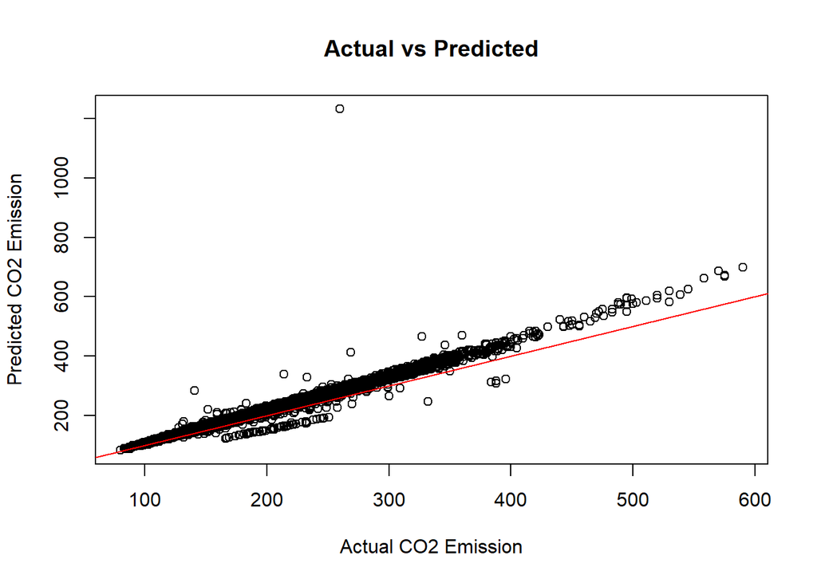

```r
plot(actual_values, predictionsLrUk, main = "Actual vs Predicted",
     xlab = "Actual CO2 Emission", ylab = "Predicted CO2 Emission")

abline(a = 0, b = 1, col = "red")
```

Vidimo zašto se RMSE razlikuje od MSE za 3 jedinice mere, imamo pretpostavku od 1200 grama CO2 na 100km za neki red. Ono glavno na ovom plotu je to da solidno pratimo liniju pravih vrednosti ali kako se prave vrednosti povećavaju tako počinjemo da više promašujemo što i nije baš sjajno, a to može biti dokaz toga da nam model i nije baš idealan.

Svakako nako svega model treba interpretirati

## Interpretacija modela CO2Emission = FCComb + FuelType + (FCComb * FuelType)

```r
summary(lmFinal)
```

```
##
## Call:
## lm(formula = CO2Emission ~ FCComb + FuelType + (FCComb * FuelType),
##     data = train)
##
## Residuals:
##      Min       1Q   Median       3Q      Max
## -15.8943  -2.5104   0.6603   1.8456  21.6496
##
## Coefficients:
##                                Estimate Std. Error  t value Pr(>|t|)
## (Intercept)                    -0.02155    0.23173   -0.093    0.926
## FCComb                         23.31710    0.02255 1033.828   <2e-16 ***
## FuelTypePremiumGasoline         0.16558    0.36876    0.449    0.653
## FuelTypeEthanol                -1.53610    1.55459   -0.988    0.323
## FuelTypeDiesel                  0.52096    1.44245    0.361    0.718
## FCComb:FuelTypePremiumGasoline -0.03497    0.03358   -1.041    0.298
## FCComb:FuelTypeEthanol         -6.84179    0.10079  -67.878   <2e-16 ***
## FCComb:FuelTypeDiesel           3.50500    0.16013   21.889   <2e-16 ***
## ---
## Signif. codes:  0 '***' 0.001 '**' 0.01 '*' 0.05 '.' 0.1 ' ' 1
##
## Residual standard error: 2.651 on 5030 degrees of freedom
## Multiple R-squared:  0.9977, Adjusted R-squared:  0.9977
## F-statistic: 3.081e+05 on 7 and 5030 DF,  p-value: < 2.2e-16
```

Prva stvar koju moramo da naznačimo je to da dodavanje interakcije dva prediktora blago komplikuje interpretaciju modela.

Ono što primećujemo je da nam fali koeficijent za običan benzin, i u termu interakcije i sama kolona, ona je uzeta kao baseline vrednost, tj. ostali koeficijenti će se posmatrati u odnosu na vozilo koje koristi benzin.

Na osnovu p vrednosti za Intercept možemo da zaključimo da on nije statistički značajan jer je njegova vrednost blizu nule.

Nakon toga, imamo koeficijent za FCComb, tj. za prediktor koji opisuje kombinovanu potrošnju goriva, i on nam govori da ćemo sa porastom od jedne jedinice u potrošnji imati porast od 23.3 jedinice emisije CO2.

FuelTypePremiumGasoline - Koeficijent vezan za kategoriju premijum benzina, on takođe nije statistički značajan na osnovu p vrednosti, tj. za taj tip goriva ćemo imati samo malu razliku u odnosu na običan benzin, što smo već i primetili pri analizi podataka.

FuelTypeEthanol - Ovaj koeficijent nije statistički značajan, vrednost mu se ne razlikuje mnogo od nule, ali ipak se više razlikuje nego koeficijenti za dizel i za premium benzin, tj. on nam kaže da ćemo imati za prosečno 1.5 jedinica manje zagađenje kod vozila koja koriste etanol.

FuelTypeDiesel - Ovaj takođe nije statistički značajan, ali ipak govori o tome da vozila koja voze dizel zagađuju malo više, što važi kada tu informaciju stavimo u kontekst analize podataka jer smo to već videli tamo.

FCComb:FuelTypePremiumGasoline - Ovaj koeficijent nije statistički značajan ali opet imamo i blagu promenu značenja, kada nismo imali razmatranje veze između tipa goriva i potrošnje koeficijent je imao pozitivan predznak, a sada on ima negativan.

FCComb:FuelTypeEthanol - Ovaj koeficijent ima jaku statističku važnost i govori o tome da ćemo imati za 6.8 manju vrednost zagađenja u proseku za vozila koja koriste etanol u odnosu na ona koja koriste običan benzin, efekat je očigledno mnogo jači sada kada posmatramo interakciju između tipa goriva i potrošnje, tj. možemo reći da porast potrošnje goriva kod vozila koja koriste etanol rezultira u manjem rastu emisija co2 u odnosu na rast koji imamo kod vozila koja koriste običan benzin.

FCComb:FuelTypeDiesel - Ovaj koeficijent je takođe statistički važan i radi suprotno od onog prethodnog, tj. govori nam o tome da porast potrošnje kod vozila koja koriste dizel utiče više na porast zagađenja nego kod vozila koja koriste običan benzin. što je i očekivano.

Statistike modela smo već komentarisali, sada možemo isprobati par drugačijih pristupa.

### Lasso & Ridge

Biblioteke:

```r
library(glmnet)
```

Podela na x koji će sadržati skup prediktora i y koji će sadržati emisije CO2 koje predvidjamo i enkodiranje faktorskih prediktora, za prediktore sa dosta kategorija ćemo koristiti frequency encoding ( ne želimo da izazovemo target leakage nekom metodom target encodinga, tj. da ne dođe do toga da nam informacije o vrednosti koju prediktujemo procure u skup podataka na osnovu kog treniramo model)

Model kolonu odbacujemo jer ima previše kategorija.

```r
model_column_index <- which(names(train) == "Model")

train <- train[, -model_column_index]

test <- test[, -model_column_index]
```

```r
for (col in names(train)) {
  if (is.character(train[[col]]) || is.factor(train[[col]])) {

    category_counts <- table(train[[col]])

    train[[col]] <- category_counts[train[[col]]]
  }
}

train <- train[, -which(names(train) == "FuelType")]
train[1,]
```

```
##   Make VehicleClass EngineSize Cylinders Transmission FCCity FCHighway FCComb
## 1   77          446        3.7         6          913   14.2       9.8   12.2
##   FCCombMPG CO2Emission FuelTypeGasoline FuelTypePremiumGasoline
## 1        23         287                1                       0
##   FuelTypeEthanol FuelTypeDiesel
## 1               0              0
```

```r
for (col in names(test)) {
  if (is.character(test[[col]]) || is.factor(test[[col]])) {

    category_counts <- table(test[[col]])

    test[[col]] <- category_counts[test[[col]]]
  }
}

test <- test[, -which(names(test) == "FuelType")]
test[1,]
```

```
##   Make VehicleClass EngineSize Cylinders Transmission FCCity FCHighway FCComb
## 1   27          362        3.5         6          397   12.7       9.1   11.1
##   FCCombMPG CO2Emission FuelTypeGasoline FuelTypePremiumGasoline
## 1        25         255                0                       1
##   FuelTypeEthanol FuelTypeDiesel
## 1               0              0
```

Nakon što smo obradili test i train dataset, delimo ih na prediktorski set i zavisni set podataka.

```r
x_train <- train[, !(names(train) %in% c("CO2Emission"))]
y_train <- train$CO2Emission

x_test <- test[, !(names(test) %in% c("CO2Emission"))]
y_test <- test$CO2Emission
```

### Lasso

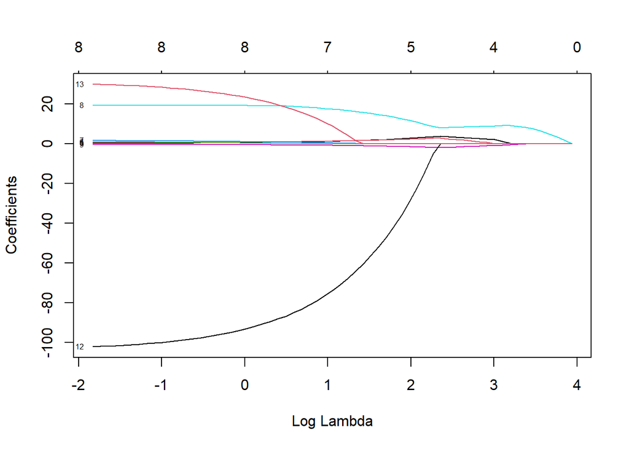

```r
lasso_model <- glmnet(x_train, y_train, alpha = 1)  # alpha = 1 for Lasso

plot(lasso_model, xvar = "lambda", label = TRUE)
```

Ono što možemo primetiti na ovom plotu jeste kako nam se lambda povećava tako se stepen regularizacije povećava tj smanjuju se koeficijenti svakog od prediktora, mi ovde tražimo najbolje lambda tj. ono lambda gde nam je vrednost greške minimalna i biramo njega za optimalan model.

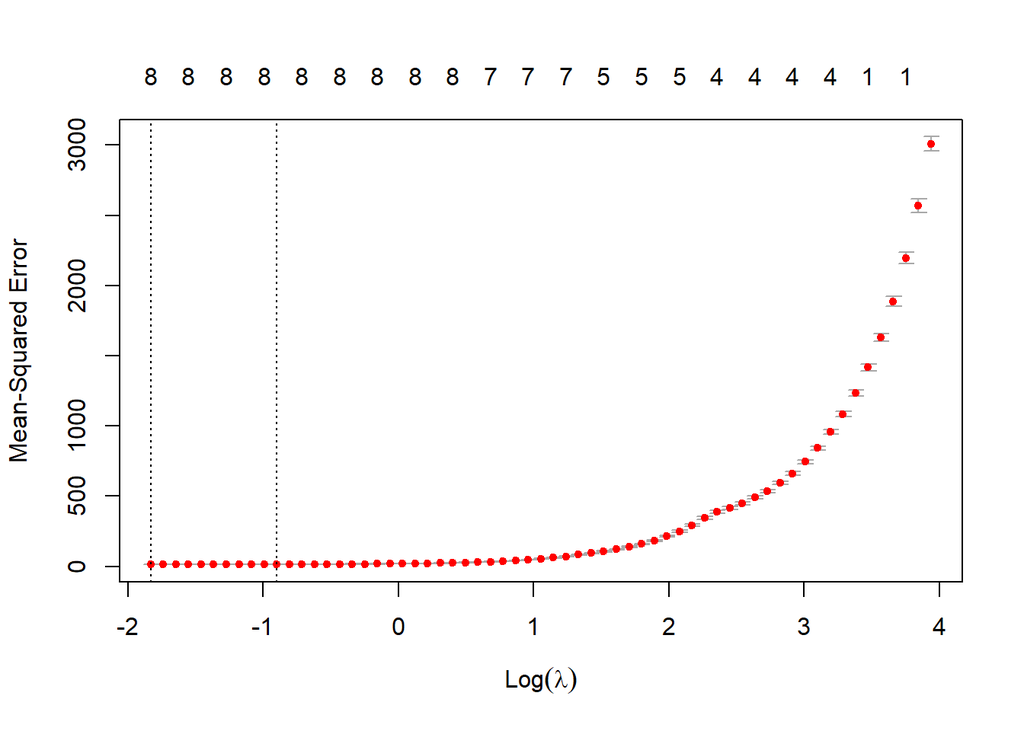

```r
cv_lasso <- cv.glmnet(data.matrix(x_train), y_train, alpha = 1)

plot(cv_lasso)
```

```r
optimal_lambda <- cv_lasso$lambda.min
cat("Optimal Lambda:", optimal_lambda, "\n")
```

```
## Optimal Lambda: 0.1605995
```

```r
lasso_model_optimal <- glmnet(x_train, y_train, alpha = 1, lambda = optimal_lambda)
```

Pronalazimo da nam je najmanji MSE kada je lambda 0,16 i koristimo tu vrednost kao finalnu.

```r
coef(lasso_model_optimal)
```

```
## 14 x 1 sparse Matrix of class "dgCMatrix"
##                                   s0
## (Intercept)               25.7224818
## Make                       .
## VehicleClass               .
## EngineSize                 0.1159038
## Cylinders                  0.4561127
## Transmission               .
## FCCity                    11.3247801
## FCHighway                  9.9405980
## FCComb                     0.5361701
## FCCombMPG                 -0.4066234
## FuelTypeGasoline           .
## FuelTypePremiumGasoline    .
## FuelTypeEthanol         -102.7557700
## FuelTypeDiesel            30.1369137
```

Sada možemo analizirati koeficijente:

Intercept nam je 25 jedinica mere

Make i Vehicle class su smatrani nevažnim i regulisani su na nulu.

Engine Size i cylinders imaju blag uticaj na emisije CO2

Kolona koja opisuju potrošnju u gradu pri promeni za jednu jedinicu mere povećava emisije CO2 za 11 jedinica u proseku, kolona za potrošnju van grada povećava emisije za 9 jedinica u proseku.

Ostale dve kolone potrošnje nemaju veliki uticaj.

Tipovi goriva kao što su benzin i premium benzin su regulisani na nulu.

Ako vozilo koristi etanol, u proseku to smanjuje izlaz CO2 za 102 jedinicu

A ako vozilo koristi dizel, to povećava emisije CO2 za 30 jedinica u proseku.

```r
lasso_predictions <- predict(lasso_model_optimal, newx = data.matrix(x_test))

rmse <- rmse(lasso_predictions, y_test)
cat("RMSE:", rmse, "\n")
```

```
## RMSE: 3.756513
```

```r
mae_value <- mae(lasso_predictions, y_test)
cat("MAE:", mae_value, "\n")
```

```
## MAE: 2.528908
```

```r
sst <- sum((y_test - mean(y_test))^2)
sse <- sum((lasso_predictions - y_test)^2)

rsq <- 1 - sse/sst
cat("R2:",rsq)
```

```
## R2: 0.9953777
```

Vidimo da model ima solidnu preciznost sa greškom 3.7 jedinica za RMSE i 2.5 za MAE, što znači da pravi malo više većih grešaka.

Model opisuje 99 posto varijabilnosti u podacima, do duše nismo sigurni da li je ovo validna metrika za testni skup.

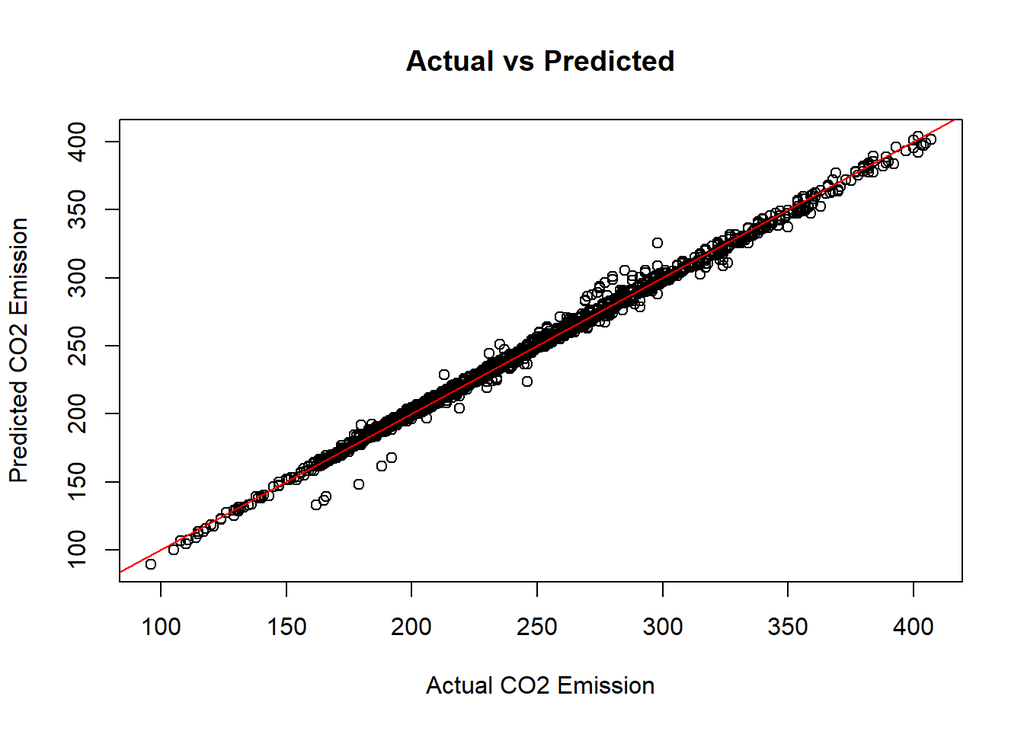

```r
plot(y_test, lasso_predictions, main = "Actual vs Predicted",
     xlab = "Actual CO2 Emission", ylab = "Predicted CO2 Emission")

abline(a = 0, b = 1, col = "red")
```

Na actual vs predicted plotu vidimo dobra svojstva, model prati dijagonalu na plotu poprilično precizno ali ipak prikazuje mali broj odstupanja.

### Ridge

Razlika izmedju Ridge i Lasso je u tome što Ridge ne može da regularizuje koeficijente na 0 već samo blizu nule, sada možemo da proverimo kako će se to odraziti na model.

Koraci su identični kao kod LASSO sem što u glmnet funkciji stavljamo alpha na nula.

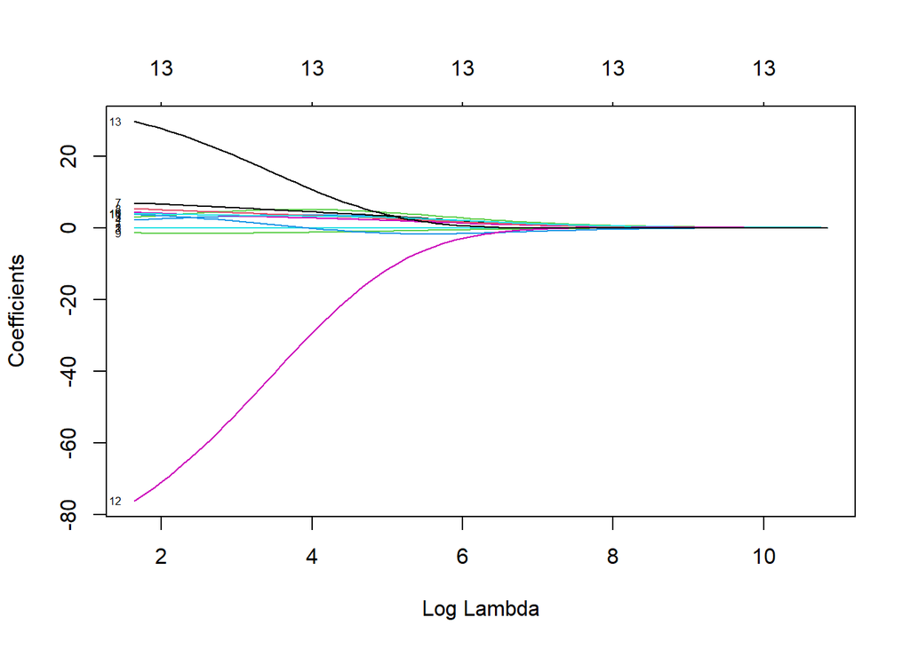

```r
ridge_model <- glmnet(x_train, y_train, alpha = 0)

plot(ridge_model, xvar = "lambda", label = TRUE)
```

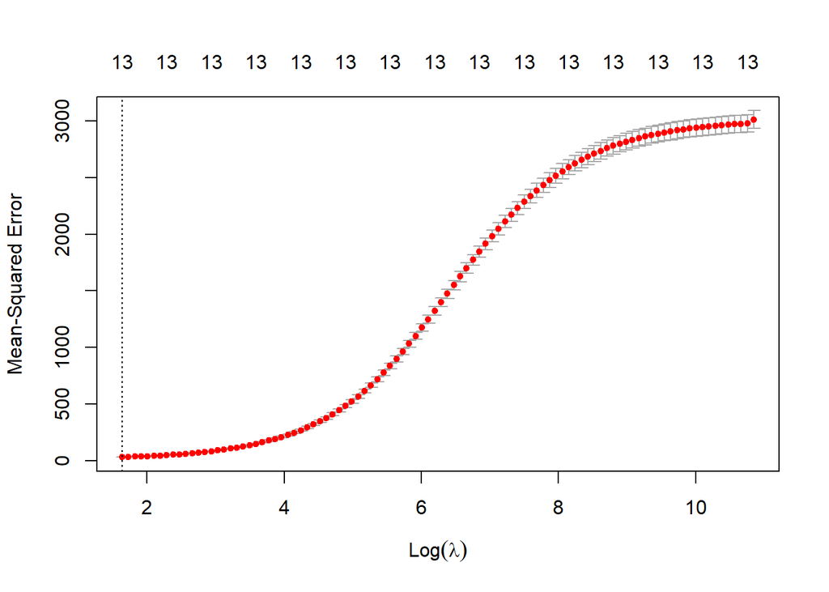

```r
cv_ridge <- cv.glmnet(data.matrix(x_train), y_train, alpha = 0)

plot(cv_ridge)
```

```r
optimal_lambda <- cv_ridge$lambda.min
cat("Optimal Lambda:", optimal_lambda, "\n")
```

```
## Optimal Lambda: 5.138007
```

```r
ridge_model_optimal <- glmnet(x_train, y_train, alpha = 0, lambda = optimal_lambda)
coef(ridge_model_optimal)
```

```
## 14 x 1 sparse Matrix of class "dgCMatrix"
##                                    s0
## (Intercept)              9.535131e+01
## Make                    -8.273628e-04
## VehicleClass            -1.847840e-03
## EngineSize               2.946555e+00
## Cylinders                2.210963e+00
## Transmission             1.686393e-03
## FCCity                   4.312906e+00
## FCHighway                6.814750e+00
## FCComb                   5.302236e+00
## FCCombMPG               -1.474492e+00
## FuelTypeGasoline         3.769382e+00
## FuelTypePremiumGasoline  3.989932e+00
## FuelTypeEthanol         -7.619327e+01
## FuelTypeDiesel           2.960775e+01
```

Vidimo u ovom slučaju da koeficijenti ne mogu biti 0, već su oni koji imaju manju važnost za model samo blizu nule, a situacija za ostale koeficijente je slična kao kod LASSO modela.

```r
ridge_predictions <- predict(ridge_model_optimal, newx = data.matrix(x_test))

rmse <- rmse(ridge_predictions, y_test)
cat("RMSE:", rmse, "\n")
```

```
## RMSE: 5.724534
```

```r
mae_value <- mae(ridge_predictions, y_test)
cat("MAE:", mae_value, "\n")
```

```
## MAE: 4.134972
```

```r
sst <- sum((y_test - mean(y_test))^2)
sse <- sum((ridge_predictions - y_test)^2)

rsq <- 1 - sse/sst
cat("R2:",rsq)
```

```
## R2: 0.9892659
```

Vidimo da ovaj model radi lošije od LASSO modela, ali su greške i dalje prihvatljive pošto nam vrednosti za CO2 variraju između 100 i 400 jedinica.

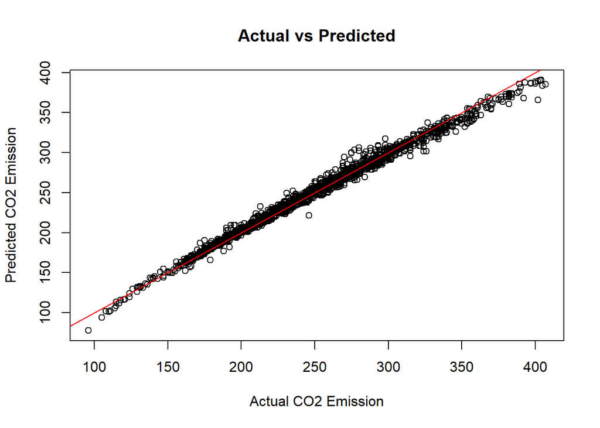

```r
plot(y_test, ridge_predictions, main = "Actual vs Predicted",
     xlab = "Actual CO2 Emission", ylab = "Predicted CO2 Emission")

abline(a = 0, b = 1, col = "red")
```

Ovde primećujemo blagu nelinearnost u plotu, za male i velike vrednosti emisija on podbacuje, ali za veliku većinu pogađa poprilično dobro.

Pošto smo zaključili da nam veza između prediktora i emisje CO2 nije baš idealno linearna, možemo da isprobamo par modela koji se ne oslanjaju na tu linearnu vezu.

Pored toga, pošto imamo poprilično veliki dataset, možda možemo da dobijemo i bolje rezultate nego one u linearnim modelima pošto će se ove metode oslanjati na veličinu dataseta za treniranje više nego linearna regresija.

## Decision tree model

Stabla odlučivanja mogu da dobro opišu nelinearne veze tako da ćemo isprobati model baziran nad njima.

Pored toga, kategorijske varijable se obradjuju automatski tako da možemo da probamo prvo da koristimo naše train podatke koji su enkodirani, a nakon toga se vratiti na one koji nisu enkodirani i uporediti rezultate.

```r
library(tree)
```

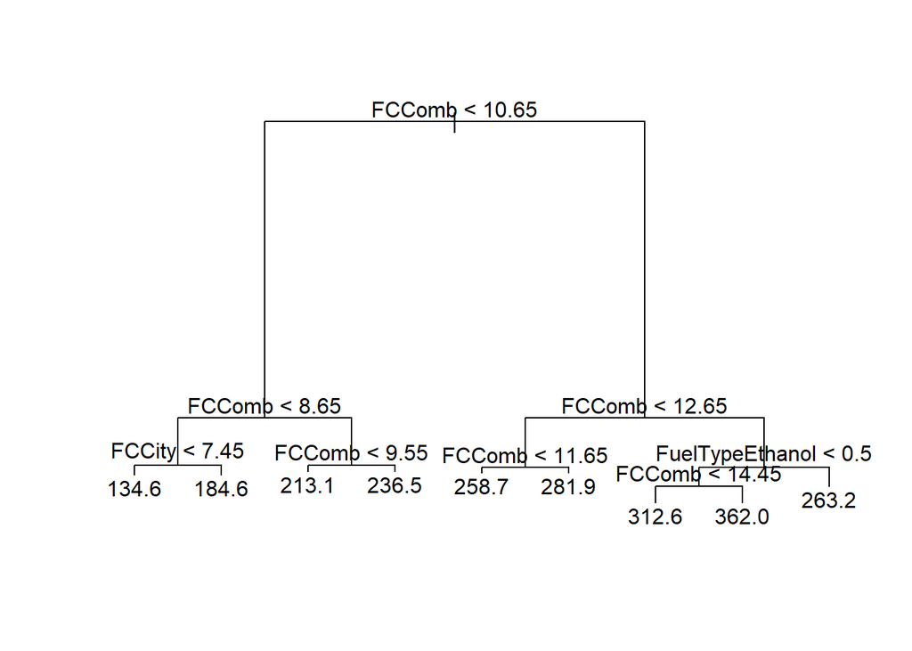

```r
treeEnc = tree(CO2Emission ~ ., data = train)

plot(treeEnc)
text(treeEnc)
```

Na plotu možemo videti kako se stablo odlučivanja formira, proverava se kombinovana potrošnja, ako je manja od 10.65 ide se u levo podstablo, pa se proverava ponovo i tom logikom se ide dok se ne dodje do listova u kojima se nalaze vrednosti emisije CO2.

Stablo samo bira na osnovu kog prediktora će deliti podatke.

```r
summary(treeEnc)
```

```
##
## Regression tree:
## tree(formula = CO2Emission ~ ., data = train)
## Variables actually used in tree construction:
## [1] "FCComb"          "FCCity"          "FuelTypeEthanol"
## Number of terminal nodes:  9
## Residual mean deviance:  169.2 = 851000 / 5029
## Distribution of residuals:
##     Min.  1st Qu.   Median     Mean  3rd Qu.     Max.
## -86.8900  -7.5940   0.2791   0.0000   7.4930  51.7700
```

Vidimo da je stablo odabralo 3 prediktora na osnovu koga će kreirati model, a to su kombinovana potrošnja, potrošnja u gradu i binardno enkodirana kategorija koja sadrži da li vozilo koristi etanol ili ne.

Metrika koja nam može nešto reći o kvalitetu ovog modela je Residual mean deviance koja označava koliko u proseku model greši za svaku tačku u datasetu, a sa vrednošću od 169.2 imamo solidan rezultat, a da bi ga malo bolje poredili sa prethodnim modelima možemo da proračunamo i MSE.

```r
trainPreds = predict(treeEnc, data = train)

mse <- mean((trainPreds - train$CO2Emission)^2)
cat("MSE:", mse, "\n")
```

```
## MSE: 168.9064
```

Možemo da primetimo da je MSE jako sličan Residual standand deviance, što i nije i čudno pošto pojedini izvori tvrde da je on pandan ovoj metrici u slučaju da stablo vrši regresiju.

(https://cdn2.hubspot.net/hubfs/402067/PDFs/Classification_and_Regression_Trees.pdf)

“Residual mean deviance: a measure of the error remaining in the tree after construction. For a regression tree, this is related to the mean squared error”

Sada ćemo izvršiti predikcije nad testnim skupom.

```r
predictions <- predict(treeEnc, newdata = test)

rmse <- rmse(predictions, y_test)
cat("RMSE:", rmse, "\n")
```

```
## RMSE: 12.93374
```

```r
mae_value <- mae(predictions, y_test)
cat("MAE:", mae_value, "\n")
```

```
## MAE: 9.566436
```

Rezultati i nisu toliko loši, grešimo za 9.5 jedinica za MAE, a 13 sa za RMSE što znači da imamo malo više većih grešaka.

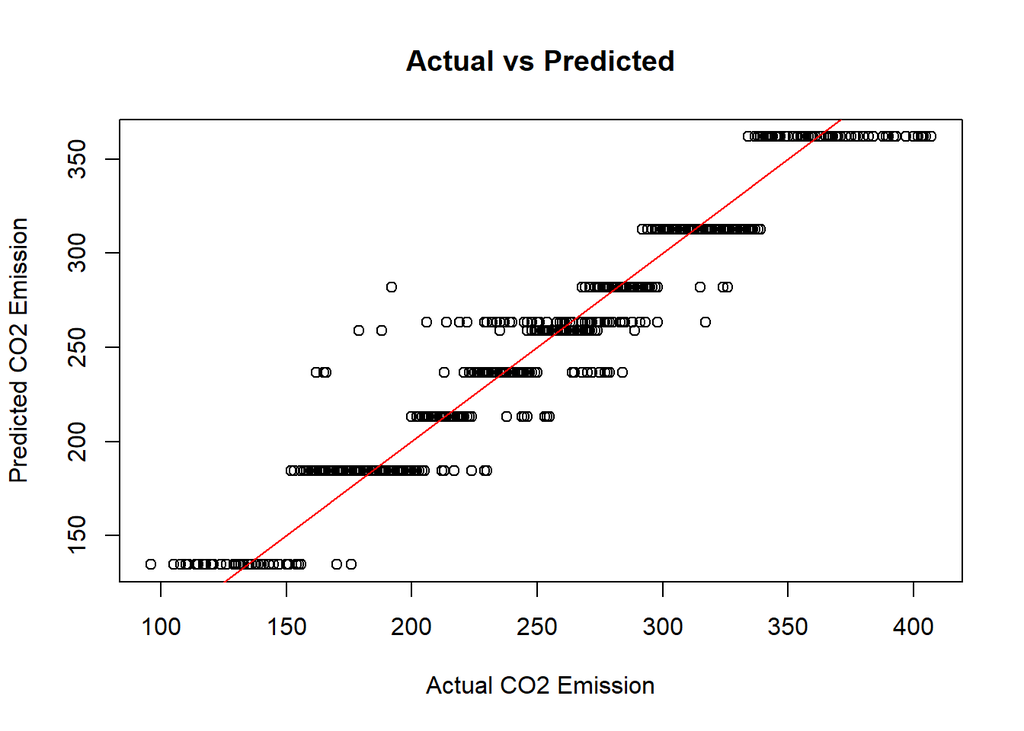

```r
plot(test$CO2Emission, predictions, main = "Actual vs Predicted",
     xlab = "Actual CO2 Emission", ylab = "Predicted CO2 Emission")

abline(a = 0, b = 1, col = "red")
```

Vidimo popriličan problem ovde, a to da ovakvo stablo nije dovoljno kompleksno kako bi modeliralo sve detalje u podacima, tj. očigledno je da su predikcije podeljene u kategorije na osnovu toga kako su vrednosti završavale u određenom listu stabla, pošto smo videli da nam je broj tih krajnjih listova 9, možemo da probamo da povećamo dubinu stabla i da ga načinimo kompleksnijim.

mindev argument označava koliko treba poboljšanje da bude u deviance metrici da bi se čvor podelio pri razvoju stabla, maje vrednosti ovog argumenta rezultiraju u kompleksnijim stablima zaključivanja

```r
treeEnc <- tree(CO2Emission ~ ., data = train, control = tree.control(nobs = nrow(train), mindev = 0.0001))

summary(treeEnc)
```

```
##
## Regression tree:
## tree(formula = CO2Emission ~ ., data = train, control = tree.control(nobs = nrow(train),
##     mindev = 1e-04))
## Variables actually used in tree construction:
## [1] "FCComb"          "FCCity"          "VehicleClass"    "FuelTypeDiesel"
## [5] "FuelTypeEthanol"
## Number of terminal nodes:  52
## Residual mean deviance:  13.46 = 67100 / 4986
## Distribution of residuals:
##    Min. 1st Qu.  Median    Mean 3rd Qu.    Max.
## -16.740  -2.136   0.000   0.000   2.275  41.660
```

Vidimo da sada imamo 52 krajnja čvora naspram 9 pre i da koristimo više prediktora, što rezultira u tume da imamo manji Residual Mean Deviance.

```r
trainPreds = predict(treeEnc, data = train)

mse <- mean((trainPreds - train$CO2Emission)^2)
cat("MSE:", mse, "\n")
```

```
## MSE: 13.31935
```

Vidimo da ovo promena daje manji MSE za trening set. A sada ono što može biti problem je da je stablo overfittovano na train dataset, tako da ćemo izvršiti proveru nad test datasetom.

```r
predictions <- predict(treeEnc, newdata = test)

rmse <- rmse(predictions, y_test)
cat("RMSE:", rmse, "\n")
```

```
## RMSE: 4.456544
```

```r
mae_value <- mae(predictions, y_test)
cat("MAE:", mae_value, "\n")
```

```
## MAE: 2.97205
```

Vidimo otprilike trostruko poboljšanje u ovim metrikama nad test datasetom što znači da je ovo zaista bolji model.

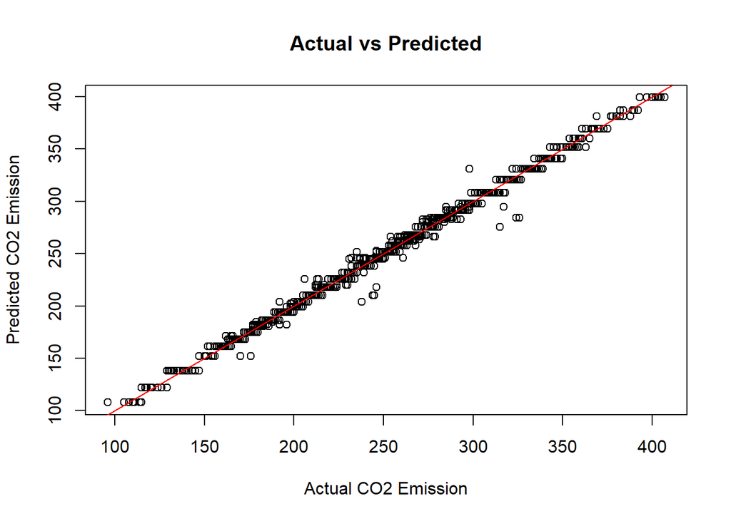

```r
plot(test$CO2Emission, predictions, main = "Actual vs Predicted",
     xlab = "Actual CO2 Emission", ylab = "Predicted CO2 Emission")

abline(a = 0, b = 1, col = "red")
```

I dalje možemo da primetimo male potkategorije vrednosti koje model pretpostavlja, ali ovo je mnogo bolja podela nego pre.

Dalje bi ovaj model mogli da još više poboljšamo kada bi mu povećali kompleksnost, ali tek u određenoj meri kako ne bi došlo do overfittinga, a to bi mogli da rešimo time što bi izveli “pruning” stabla, tj. metodu regularizacije za ovakve modele gde se odsecaju pojedine grane stabla kako bi smanjili šanse za overfitting.

## Random forest model

Ovaj model se gradi nad konceptom stabla odlučivanja tako što se kreira nad više stabla odlučivanja kako bi kombinovanjem rezultata tih stabala dolazio do zaključaka (ensemble).

Pored toga ovakav model koristi “bagging” (Bootstrap Aggregating) tj. metodu ansambla modela gde se za svaki manji model vrši bootstraping podskupa podataka, a nako što se ti manji modeli istreniraju, najbolji rezultat se bira vađenjem proseka rezultata izmedju različitih modela u slučaju regresije.

```r
library(randomForest)
rfEnc = randomForest(CO2Emission ~ ., data = train)

rfEnc
```

```
##
## Call:
##  randomForest(formula = CO2Emission ~ ., data = train)
##                Type of random forest: regression
##                      Number of trees: 500
## No. of variables tried at each split: 4
##
##           Mean of squared residuals: 7.776572
##                     % Var explained: 99.74
```

Vidimo da je ovo regresija kao što smo očekivali, broj stabla je 500 što je default ali ćemo videti da li je potreban toliki broj.

Pored toga, MSE se računa na out of bag podacima tako da bi trebao da bude sličan onom kojem ćemo dobiti nad testnim podacima ali to ćemo svakako testirati.

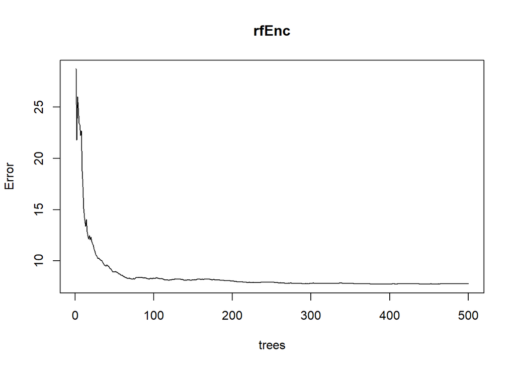

```r
plot(rfEnc)
```

Na osnovu ovog plota možemo da primetimo da nam je 500 stabla mnogo pošto je greška već spala na minimum već negde oko dvestotog stabla

Pored toga, možemo da povećamo broj promenljivih koje stablo isprobava pri svakoj podeli korišćenjem mtry argumenta.

```r
rfEnc = randomForest(CO2Emission ~ ., data = train, ntree = 200, mtry = 12)

rfEnc
```

```
##
## Call:
##  randomForest(formula = CO2Emission ~ ., data = train, ntree = 200,      mtry = 12)
##                Type of random forest: regression
##                      Number of trees: 200
## No. of variables tried at each split: 12
##
##           Mean of squared residuals: 6.355275
##                     % Var explained: 99.79
```

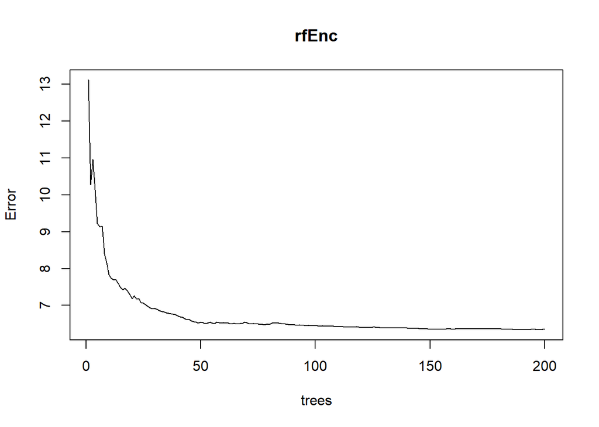

```r
plot(rfEnc)
```

Možemo da primetimo da smo dosta smanjli MSE i da smo povećali R2. Sada model možemo da proverimo model nad test podacima.

```r
predictions <- predict(rfEnc, newdata = test)

mse <- mse(predictions, y_test)
cat("MSE:", mse, "\n")
```

```
## MSE: 8.712825
```

```r
rmse <- rmse(predictions, y_test)
cat("RMSE:", rmse, "\n")
```

```
## RMSE: 2.95175
```

```r
mae_value <- mae(predictions, y_test)
cat("MAE:", mae_value, "\n")
```

```
## MAE: 2.115863
```

MSE za test skup je malo gori od onog koji je izračunat nad out of bag podacima kada je model treniran, ali svakako ne mnogo.

Imamo odlične rezultate za RMSE i za MAE, veoma su slični onim iz modela linearne regresije koji je podešavan ručno.

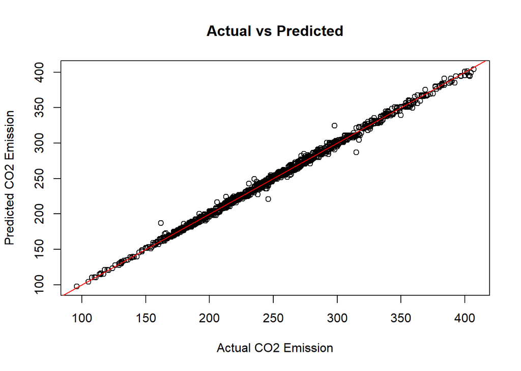

```r
plot(test$CO2Emission, predictions, main = "Actual vs Predicted",
     xlab = "Actual CO2 Emission", ylab = "Predicted CO2 Emission")


abline(a = 0, b = 1, col = "red")
```

Očigledan je dobar fit ovog modela, tačke skoro idealno prate dijagonalu, imamo samo par malih odstupanja.

Za kraj možemo isprobati neke gradient boosting metode.

## Gradient boost - xgboost

Ovi modeli koriste više slabih modela mašinskog učenja kako bi napravili jedan jak model. Na početku se kreira i fituje jedan inicijalni model npr. stablo odlučivanja, a nakon toga drugi model koji se fokusira na to da pogodi kako treba za slučajeve u kojima je prvi promašio.

Ovo je takođe metoda ansambla kao i bagging, ali se razlikuje u tome što svaki sledeći model se trudi da ispravi greške svog prethodnika, tj. on boostuje rezultat.

Nakon toga, ovaj proces se ponavlja puno puta dok se ne dodje do uslova za zaustavljanje.

Mi ćemo isprobati par gradient boost modela, prvi je xgboost.

```r
library(xgboost)
```

Možemo da isprobamo dva pristupa, da pošaljemo sve feature pa da sam algoritam izvrši nekakvu vrstu feature selection-a tako što će konstruisati stabla odlučivanja u kojima se prediktorima sa boljim rezultatima daje veća važnost ili da pošaljemo samo FCComb i FuelType kao što smo imali kod linearnog modela.

Kod druge opcije možemo proveriti kako se ovaj jači model ponaša sa neviđenim podacima (ukData).

```r
x_train_alt = train[c("FCComb", "FuelTypeGasoline", "FuelTypePremiumGasoline", "FuelTypeEthanol", "FuelTypeDiesel")]
y_train_alt = train$CO2Emission

x_test_alt = test[c("FCComb", "FuelTypeGasoline", "FuelTypePremiumGasoline", "FuelTypeEthanol", "FuelTypeDiesel")]
y_test_alt = test$CO2Emission
```

Pre nego što krenemo treba da postavimo početne parametre, menjaćemo ih u zavisnosti od rezultata, ali se svakako za ozbiljnije primene može uraditi hyperparameter tuning.

```r
params <- list(
  objective = "reg:squarederror",
  max_depth = 8,
  eta = 0.2
)
```

objective - specifikacija loss funkcije, u ovom slučaju RMSE pošto radimo regresiju

max_depth - maksimalna dubina svakog od stabala koje se koriste pri treniranju modela

eta - learning rate tj. stopa učenja modela, koristimo je kako bi sprečili overfitting

To su samo neki od hiperparametara koje je moguće postaviti.

```r
# Train the XGBoost model
xgbAll <- xgboost(data = as.matrix(x_train), label = y_train, params = params, nrounds = 300, verbose = FALSE)

xgbAll
```

```
## ##### xgb.Booster
## raw: 2.2 Mb
## call:
##   xgb.train(params = params, data = dtrain, nrounds = nrounds,
##     watchlist = watchlist, verbose = verbose, print_every_n = print_every_n,
##     early_stopping_rounds = early_stopping_rounds, maximize = maximize,
##     save_period = save_period, save_name = save_name, xgb_model = xgb_model,
##     callbacks = callbacks)
## params (as set within xgb.train):
##   objective = "reg:squarederror", max_depth = "8", eta = "0.2", validate_parameters = "TRUE"
## xgb.attributes:
##   niter
## callbacks:
##   cb.evaluation.log()
## # of features: 13
## niter: 300
## nfeatures : 13
## evaluation_log:
##     iter train_rmse
##        1 202.515958
##        2 162.204464
## ---
##      299   1.036699
##      300   1.036339
```

```r
xgbAlt <- xgboost(data = as.matrix(x_train_alt), label = y_train_alt, params = params, nrounds = 300, verbose = FALSE)

xgbAlt
```

```
## ##### xgb.Booster
## raw: 1 Mb
## call:
##   xgb.train(params = params, data = dtrain, nrounds = nrounds,
##     watchlist = watchlist, verbose = verbose, print_every_n = print_every_n,
##     early_stopping_rounds = early_stopping_rounds, maximize = maximize,
##     save_period = save_period, save_name = save_name, xgb_model = xgb_model,
##     callbacks = callbacks)
## params (as set within xgb.train):
##   objective = "reg:squarederror", max_depth = "8", eta = "0.2", validate_parameters = "TRUE"
## xgb.attributes:
##   niter
## callbacks:
##   cb.evaluation.log()
## # of features: 5
## niter: 300
## nfeatures : 5
## evaluation_log:
##     iter train_rmse
##        1  202.51647
##        2  162.20449
## ---
##      299    2.43821
##      300    2.43821
```

Vidimo gori rezultat u slučaju gde koristimo samo FCComb i enkodiran FuelType, sada ćemo probati ova dva modela na originalnom testnom skupu.

**xgboost sa svim prediktorima**

```r
predictions <- predict(xgbAll, as.matrix(x_test))

rmse <- rmse(predictions, y_test)
cat("RMSE:", rmse, "\n")
```

```
## RMSE: 2.853747
```

```r
mae_value <- mae(predictions, y_test)
cat("MAE:", mae_value, "\n")
```

```
## MAE: 2.136959
```

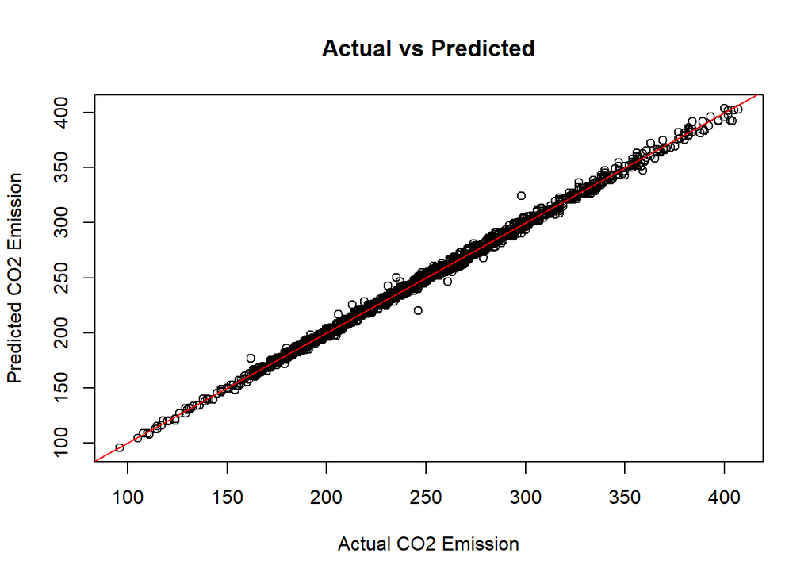

```r
plot(test$CO2Emission, predictions, main = "Actual vs Predicted",
     xlab = "Actual CO2 Emission", ylab = "Predicted CO2 Emission")

abline(a = 0, b = 1, col = "red")
```

Primećujemo da ovaj model odlično pretpostavlja i na testnom skupu, sada da probamo drugi koji je ograničen prediktorima.

**xgboost sa FCComb i enkodiranim FuelType za prediktore**

```r
predictions <- predict(xgbAlt, as.matrix(x_test_alt))

rmse <- rmse(predictions, y_test_alt)
cat("RMSE:", rmse, "\n")
```

```
## RMSE: 2.815959
```

```r
mae_value <- mae(predictions, y_test_alt)
cat("MAE:", mae_value, "\n")
```

```
## MAE: 2.126629
```

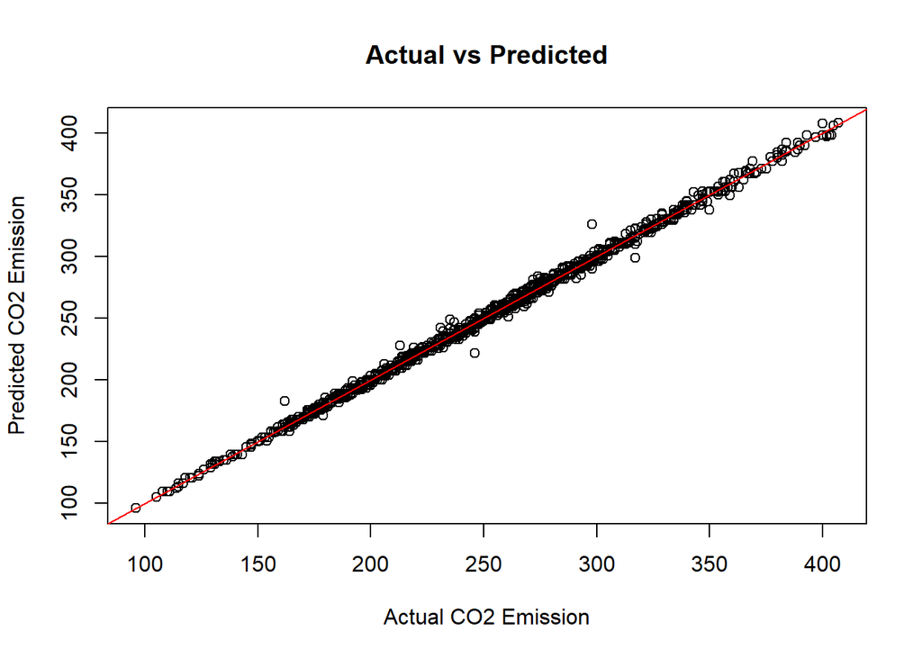

```r
plot(test$CO2Emission, predictions, main = "Actual vs Predicted",
     xlab = "Actual CO2 Emission", ylab = "Predicted CO2 Emission")

abline(a = 0, b = 1, col = "red")
```

Ovde imamo jako čudan rezultat, a to je da su metrike iz nekog razloga bolje na ovom modelu, izgleda da onaj prvi model koji drži sve prediktore ima blag overfitting.

**Poređenje sa modelom linearne regresije nad ukData skupom podataka**

```r
x_testUK = ukDataClean[c("FCComb", "FuelTypeGasoline", "FuelTypePremiumGasoline", "FuelTypeEthanol", "FuelTypeDiesel")]
y_testUK = ukDataClean$CO2Emission
```

```r
predictionsXGB <- predict(xgbAlt, as.matrix(x_testUK))

rmse <- rmse(predictionsXGB, y_testUK)
cat("RMSE:", rmse, "\n")
```

```
## RMSE: 19.83852
```

```r
mae_value <- mae(predictionsXGB, y_testUK)
cat("MAE:", mae_value, "\n")
```

```
## MAE: 16.78179
```

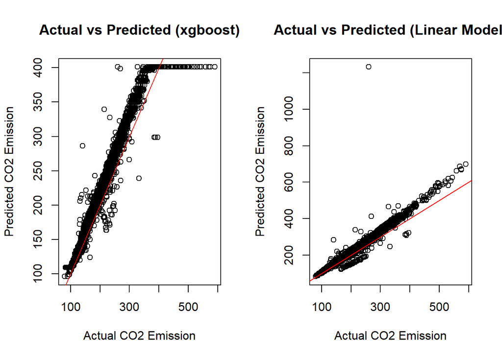

```r
par(mfrow = c(1, 2))


plot(y_testUK, predictionsXGB, main = "Actual vs Predicted (xgboost)",
     xlab = "Actual CO2 Emission", ylab = "Predicted CO2 Emission")
abline(a = 0, b = 1, col = "red")

plot(y_testUK, predictionsLrUk, main = "Actual vs Predicted (Linear Model)",
     xlab = "Actual CO2 Emission", ylab = "Predicted CO2 Emission")
abline(a = 0, b = 1, col = "red")
```

```r
par(mfrow = c(1, 1))
```

Prema metrikama za RMSE i MAE pomislili bi da imamo bolji model ali je očigledno da imamo ozbiljan problem ako pogledamo u plot pravih i pretpostavljenih vrednosti, a to je da model ne pretpostavlja vrednosti veće u 400, jer je to bio maksimum u trening datasetu, a u ovom imamo i veće realne vrednosti, a takođe ovaj model počinje da promašuje kako se vrednosti CO2 povećavaju, isto kao i model linearne regresije.

Svakako, sve ovo smatramo našom greškom, koristimo neke pretpostavljene vrednosti hiperparametara što sigurno nije dobro.

Ovakve modele je teže interpretirati ali svakako ima načina, jedan od njih je da proverimo važnost svakog prediktora tj. feature importance

```r
xgb.importance(model = xgbAlt)
```

```
##                    Feature         Gain      Cover  Frequency
## 1:                  FCComb 9.524398e-01 0.87609174 0.73015487
## 2:         FuelTypeEthanol 4.341884e-02 0.03674772 0.02846023
## 3:          FuelTypeDiesel 4.078470e-03 0.05000398 0.01832482
## 4:        FuelTypeGasoline 3.163212e-05 0.02440954 0.14594989
## 5: FuelTypePremiumGasoline 3.129247e-05 0.01274702 0.07711019
```

Ono što je važno za odredjivanje važnosti prediktivne moći prediktora je Gain kolona.

Vidimo da u modelu koji ima ograničene prediktore najveći gain ima FCComb kolona, što znači da ovaj prediktor najviše doprinosi našem modelu.

Sada možemo da proverimo to isto za model koji ima sve prediktore.

```r
xgb.importance(model = xgbAll)
```

```
##                     Feature         Gain        Cover    Frequency
##  1:                  FCComb 9.310357e-01 0.2772521320 0.1135916164
##  2:         FuelTypeEthanol 4.332857e-02 0.0099635631 0.0030168307
##  3:                  FCCity 1.600676e-02 0.2326824927 0.2278501111
##  4:               FCHighway 4.782958e-03 0.1856791383 0.1865671642
##  5:          FuelTypeDiesel 4.003960e-03 0.0233894506 0.0042553191
##  6:                    Make 2.464332e-04 0.0713099950 0.1810733566
##  7:            Transmission 2.011054e-04 0.0742581422 0.0861225786
##  8:              EngineSize 1.828768e-04 0.0704647898 0.0795173071
##  9:            VehicleClass 1.388777e-04 0.0330884462 0.0990790727
## 10:               Cylinders 2.746289e-05 0.0165772409 0.0049539536
## 11:        FuelTypeGasoline 2.369746e-05 0.0026844296 0.0096538584
## 12: FuelTypePremiumGasoline 2.116866e-05 0.0019926276 0.0037154652
## 13:               FCCombMPG 4.464144e-07 0.0006575518 0.0006033661
```

Ista situacija je i ovde, FCComb i dalje najviše doprinosi i kod ovog modela.

## LightGBM model

Ova implementacija gradient boost algoritma pruža dobre brzine treniranja i dobru memorijsku efikasnost, što je čini pogodnom za velike skupove podataka.

U poređenju sa xgboost implementacijom, LightGBM pruža bolju memorijsku efikasnost, omogućava automatsko enkodiranje kategorijskih prediktora, i još neke prednosti.

```r
library(lightgbm)
```

Hiperparametri:

```r
params <- list(
  objective = "regression",
  metric = "rmse",
  learning_rate = 0.3,
  max_depth = 8,
  num_leaves = 50,
  verbosity = -1
)
```

Podaci za treniranje:

```r
train <- lgb.Dataset(data = as.matrix(x_train_alt), label = y_train_alt)
test <- lgb.Dataset(data = as.matrix(x_test_alt), label = y_test_alt, reference = train)
```

Treniranje modela:

```r
lgb_model <- lgb.train(params, train, nrounds = 300, valids = list(test = test) , verbose = 0, early_stopping_rounds = 5)
```

```r
lgb_model$best_score
```

```
## [1] 2.938689
```

Koristimo early stopping kako bi zaustavili treniranje ako nema poboljšanja u metrici nakon 5 iteracija.

Sada da vidimo kako se ponaša sa ukData skupom podataka.

```r
predictions <- predict(lgb_model, as.matrix(x_testUK))

rmse <- rmse(predictions, y_testUK)
cat("RMSE:", rmse, "\n")
```

```
## RMSE: 19.50497
```

```r
mae_value <- mae(predictions, y_testUK)
cat("MAE:", mae_value, "\n")
```

```
## MAE: 16.30956
```

Svakako deluje da imamo solidne rezultate u obe metrike, sada da proverimo plot.

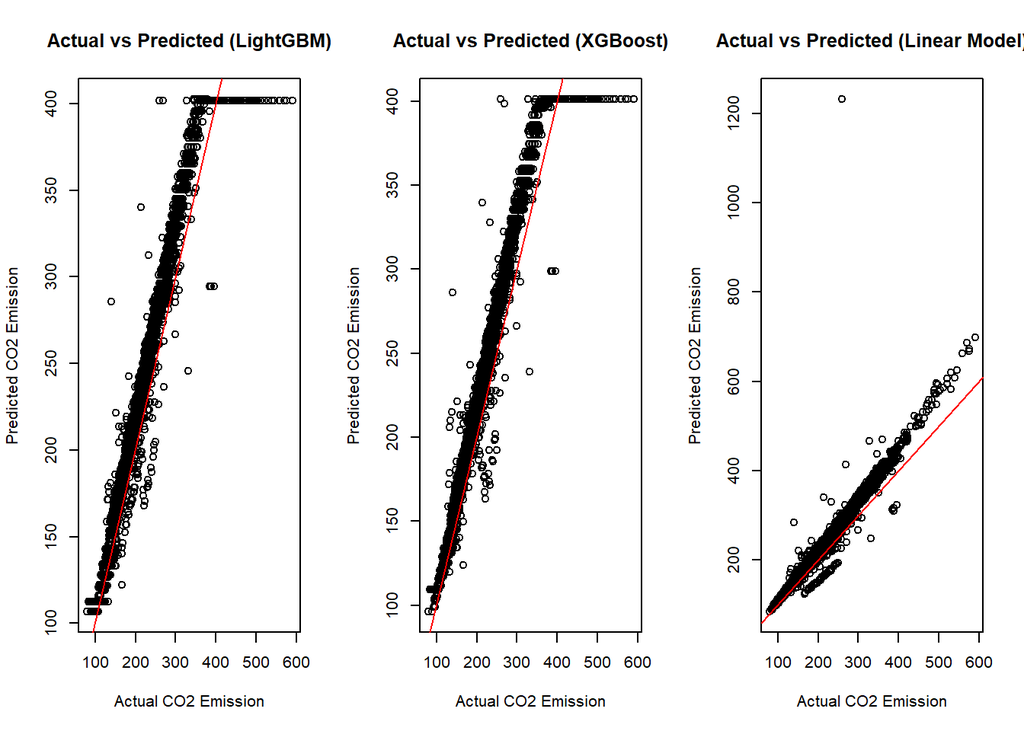

```r
par(mfrow = c(1, 3))


plot(y_testUK, predictions, main = "Actual vs Predicted (LightGBM)",
     xlab = "Actual CO2 Emission", ylab = "Predicted CO2 Emission")
abline(a = 0, b = 1, col = "red")

plot(y_testUK, predictionsXGB, main = "Actual vs Predicted (XGBoost)",
     xlab = "Actual CO2 Emission", ylab = "Predicted CO2 Emission")
abline(a = 0, b = 1, col = "red")

plot(y_testUK, predictionsLrUk, main = "Actual vs Predicted (Linear Model)",
     xlab = "Actual CO2 Emission", ylab = "Predicted CO2 Emission")
abline(a = 0, b = 1, col = "red")
```

```r
par(mfrow = c(1, 1))
```

Evidentno je da imamo identičan problem kao i kod XGBoost implementacije, možda bi ga mogli rešiti skaliranjem vrednosti emisija CO2, ali svakako van toga i ovaj model pravi dobre predikcije.